# Health-Related Social Influence Strategies in Overweight Romantic Couples: Daily Associations with Physical Activity and Affect for Targets and Actors

Pascal Küng, MSc (ORCID: 0000-0001-7346-9414), Corina Berli, PhD (ORCID: 0000-0002-5078-3539), Patrick S. Höhener, MSc (ORCID: 0000-0003-3635-2799), Robert Tobias, PhD (ORCID: 0000-0001-7972-122X), Urte Scholz, PhD (ORCID: 0000-0003-0184-5921)

2024-09-28

# Setup and loading

```r
df <- readRDS(file = 'DataSet_Subset.rds')
```

# Modelling

We define the following functions to facilitate reporting of the models.

```r
# Defining common elements
common_within_person_effects <- c(
  '(Intercept)',
  '---WITHIN-PERSON EFFECTS---',
  'PSC_agent_cw',
  'NSC_agent_cw',
  'sbyday',
  'weeknd2',
  'weartime_cw'
)

common_between_person_effects <- c(
  'PSC_agent_cb',
  'NSC_agent_cb',
  'weartime_cb'
)

common_random_effects <- c(
  'Std.Dev.(Intercept)|CoupleID',
  'Std.Dev.PSC_agent_cw|CoupleID',
  'Std.Dev.NSC_agent_cw|CoupleID',
  'Cor.PSC_agent_cw.(Intercept)|CoupleID',
  'Cor.NSC_agent_cw.(Intercept)|CoupleID',
  'Cor.NSC_agent_cw.PSC_agent_cw|CoupleID'
)

common_model_info <- c(
  'Within-group standard error',
  'dispersion',
  'AR1'
)

# Order for report
order_rep <- c(
  common_within_person_effects,
  '---BETWEEN-PERSON EFFECTS---',
  common_between_person_effects,
  '---RANDOM-EFFECTS---',
  common_random_effects,
  '---------MODEL INFO---------',
  common_model_info
)

# Order for sensitivity analysis
order_sens <- c(
  common_within_person_effects,
  'Sup_agent_cw',
  'Sup_target_cw',
  'time_spent_cw',
  'intention_agent_lagged_cw',
  'intention_target_lagged_cw',
  'self_efficacy_agent_lagged_cw',
  'self_efficacy_target_lagged_cw',
  'plan_agent_lagged_cw',
  'plan_target_lagged_cw',
  'risk_perception_agent_cw',
  'risk_perception_target_cw',
  'perceived_benfeits_agent_cw',
  'perceived_benfeits_target_cw',
  '---BETWEEN-PERSON EFFECTS---',
  common_between_person_effects,
  'Sup_agent_cb',
  'Sup_target_cb',
  'time_spent_cb',
  'intention_agent_lagged_cb',
  'intention_target_lagged_cb',
  'self_efficacy_agent_lagged_cb',
  'self_efficacy_target_lagged_cb',
  'plan_agent_lagged_cb',
  'plan_target_lagged_cb',
  'risk_perception_agent_cb',
  'risk_perception_target_cb',
  'perceived_benfeits_agent_cb',
  'perceived_benfeits_target_cb',
  'reldur_cb',
  'page',
  'sage',
  'pbmi',
  'sbmi',
  'sb0kih01',
  'sb0sex01',
  'pb0sex01',
  'groupdyadic action control',
  'groupindividual action control',
  '---RANDOM-EFFECTS---',
  common_random_effects,
  '---------MODEL INFO---------',
  common_model_info
)



full_report <- function(model, order) {
  if (class(model) == 'glmmTMB') {
    return(report_glmmTMB(model, order))
  } else {
    return(report_nlme(model, order))
  }
}


report_glmmTMB <- function(model, order) {
  # Extracting model parameters and creating the initial dataframe
  rep_df <- as.data.frame(model_parameters(model, exponentiate = TRUE))[,c('Parameter', 'Coefficient', 'SE', 'p', 'CI_low', 'CI_high', 'Effects', 'Component')]

  # Removing rows where the Parameter includes 'factor'
  rep_df <- rep_df[rep_df$Effects != 'random',]


  # Adding confidence intervals

  int <- as.data.frame(confint(model))

  intt <- int[!grepl('factor', rownames(int)),]
  intervals <- intt[grepl('CoupleID', rownames(intt)),]


  df_intervals <- data.frame('Parameter' = rownames(intervals),
                             'Coefficient' = intervals$Estimate,
                             'SE' = NA,
                             'CI_low' = intervals$`2.5 %`,
                             'CI_high' = intervals$`97.5 %`,
                             'p' = NA,
                             'Effects' = 'random',
                             'Component' = 'conditional')

  rep_df <- rbind(rep_df, df_intervals)


  # Extracting the AR1 coefficient from the model
  ar1 <- capture.output(summary(model)$varcor)
  if (length(grep("ar1", ar1)) > 0) {
    ar1_value <- as.numeric(strsplit(ar1[grep("ar1", ar1)], "\\(ar1\\)")[[1]][2])
  } else {
    ar1_value <- NA
  }


  # Combining and reporting

  rep_df <- rep_df %>%
    add_row(Parameter = '---WITHIN-PERSON EFFECTS---') %>%
    add_row(Parameter = '---BETWEEN-PERSON EFFECTS---') %>%
    add_row(Parameter = '---RANDOM-EFFECTS---') %>%
    add_row(Parameter = 'Within-group standard error') %>%
    add_row(Parameter = '---------MODEL INFO---------') %>%
    add_row(Parameter = 'AR1', Coefficient = ar1_value)

  rep_df
  rep_df[rep_df$Component == 'dispersion' & rep_df$Parameter == '(Intercept)', ]$Parameter <- 'dispersion'


  # Reorder the dataframe based on 'order'
  rep_df$Parameter[rep_df$Parameter == "sbwwear_cw"] <- 'weartime_cw'
  rep_df$Parameter[rep_df$Parameter == "sbwwear_cb"] <- 'weartime_cb'
  rep_df$Parameter[rep_df$Parameter == "pbwwear_cw"] <- 'weartime_cw'
  rep_df$Parameter[rep_df$Parameter == "pbwwear_cb"] <- 'weartime_cb'


  rep_df <- rep_df[match(order, rep_df$Parameter),]

  # Call function for rounding and adding stars
  rep_df <- process_coefficients(rep_df)


  return(rep_df)
}



report_nlme <- function(model, order) {
  # Extracting fixed effects
  rep_df <- as.data.frame(model_parameters(model))[,c('Parameter', 'Coefficient', 'SE', 'p', 'CI_low', 'CI_high', 'Effects')]

  rep_df <- tryCatch({

      # Confidence intervals of random effects
      int <- intervals(model)
      int_rand <- as.data.frame(int$reStruct)

      # add AR1
      int_ar1 <- as.data.frame(int$corStruct)

      if (nrow(int_ar1) > 0) {
        rownames(int_ar1) <- c('AR1')
        colnames(int_ar1) <- colnames(int_rand)
        int_rand <- rbind(int_rand, int_ar1)
      } else {
        # Create a row with NA values
        na_row <- setNames(data.frame(matrix(NA, ncol = ncol(int_rand), nrow = 1)), colnames(int_rand))
        rownames(na_row) <- 'AR1'
        int_rand <- rbind(int_rand, na_row)
      }

      # Add Confint for sigma
      int_resid <- as.data.frame(int$sigma)

      int_rand[nrow(int_rand) + 1,] <- c(int_resid[1, 1], int_resid[2, 1], int_resid[3, 1])
      rownames(int_rand)[nrow(int_rand)] <- 'Within-group standard error'




      # Construct df

      int_df <- data.frame(
        Parameter = rownames(int_rand),
        Coefficient = int_rand$CoupleID.est.,
        SE = NA,
        CI_low = int_rand$CoupleID.lower,
        CI_high = int_rand$CoupleID.upper,
        p = NA,
        Effects = 'random'
      )

      # Combine
      rep_df <- rep_df[rep_df$Effects != 'random',]

      rep_df <- rbind(rep_df, int_df)
      rep_df$Parameter[rep_df$Parameter == 'sd((Intercept))'] <- 'Std.Dev.(Intercept)|CoupleID'
      rep_df$Parameter[rep_df$Parameter == 'sd(PSC_agent_cw)'] <- 'Std.Dev.PSC_agent_cw|CoupleID'
      rep_df$Parameter[rep_df$Parameter == 'sd(NSC_agent_cw)'] <- 'Std.Dev.NSC_agent_cw|CoupleID'
      rep_df$Parameter[rep_df$Parameter == 'cor((Intercept),PSC_agent_cw)'] <- 'Cor.PSC_agent_cw.(Intercept)|CoupleID'
      rep_df$Parameter[rep_df$Parameter == 'cor((Intercept),NSC_agent_cw)'] <- 'Cor.NSC_agent_cw.(Intercept)|CoupleID'
      rep_df$Parameter[rep_df$Parameter == 'cor(PSC_agent_cw,NSC_agent_cw)'] <- 'Cor.NSC_agent_cw.PSC_agent_cw|CoupleID'
      rep_df$Parameter[rep_df$Parameter == 'cor(NSC_agent_cw,PSC_agent_cw)'] <- 'Cor.NSC_agent_cw.PSC_agent_cw|CoupleID'
      rep_df
    }, error = function(e) {
      rep_df$Parameter[rep_df$Parameter == "SD (Intercept)"] <- 'Std.Dev.(Intercept)|CoupleID'
      rep_df$Parameter[rep_df$Parameter == 'SD (PSC_agent_cw)'] <- 'Std.Dev.PSC_agent_cw|CoupleID'
      rep_df$Parameter[rep_df$Parameter == 'SD (NSC_agent_cw)'] <- 'Std.Dev.NSC_agent_cw|CoupleID'
      rep_df$Parameter[rep_df$Parameter == 'Cor (Intercept~PSC_agent_cw)'] <- 'Cor.PSC_agent_cw.(Intercept)|CoupleID'
      rep_df$Parameter[rep_df$Parameter == 'Cor (Intercept~NSC_agent_cw)'] <- 'Cor.NSC_agent_cw.(Intercept)|CoupleID'
      rep_df$Parameter[rep_df$Parameter == 'Cor (PSC_agent_cw~NSC_agent_cw)'] <- 'Cor.NSC_agent_cw.PSC_agent_cw|CoupleID'
      rep_df$Parameter[rep_df$Parameter == 'Cor (NSC_agent_cw~PSC_agent_cw)'] <- 'Cor.NSC_agent_cw.PSC_agent_cw|CoupleID'
      rep_df$Parameter[rep_df$Parameter == 'SD (Observations)'] <- 'Within-group standard error'
      rep_df
    }
  )

  # Finishing touches
  rep_df <- rep_df %>%
    add_row(Parameter = '---WITHIN-PERSON EFFECTS---') %>%
    add_row(Parameter = '---BETWEEN-PERSON EFFECTS---') %>%
    add_row(Parameter = '---RANDOM-EFFECTS---') %>%
    add_row(Parameter = '---------MODEL INFO---------') %>%
    add_row(Parameter = 'dispersion') %>%
    add_row(Parameter = 'sbwwear_cb') %>%
    add_row(Parameter = 'sbwwear_cw')


  # Reorder the dataframe based on 'order'
  rep_df <- rep_df[match(order, rep_df$Parameter),]

  # Call function for rounding and adding stars
  rep_df <- process_coefficients(rep_df)

  return(rep_df)
}





process_coefficients <- function(df) {
  # Round
  df[, c(2, 3, 5, 6)] <- round(df[, c(2, 3, 5, 6)], 2)
  df[, 4] <- round(df[, 4], 3)

  # Add stars
  df$Coefficient <- as.character(sprintf("%.2f", df$Coefficient))
  df$Coefficient <- ifelse(is.na(df$p), df$Coefficient,
                           ifelse(df$p < 0.001, paste0(df$Coefficient, "***"),
                                  ifelse(df$p < 0.01, paste0(df$Coefficient, "**"),
                                         ifelse(df$p < 0.05, paste0(df$Coefficient, "*"),
                                                df$Coefficient))))
  return(df)
}
```

## Models

### Models for TARGET

#### Positive Affect - Target

Due to convergence Issue, AR1 had to be replaced with an unstructured error covariance matrix.

```r
# Base Model
posaff_target <- lme(
    fixed = Paff_target~
        PSC_agent_cw + NSC_agent_cw +
        sbyday + weeknd2 +
        PSC_agent_cb + NSC_agent_cb,
    data = as.data.frame(df),
    random = ~ PSC_agent_cw + NSC_agent_cw | CoupleID,
    #correlation = corAR1(form = ~ 1 | CoupleID),
    na.action = na.omit,
    control = lmeControl(opt='optim',
                         maxIter = 1e4,
                         msMaxEval = 1e4)
)

check_singularity(posaff_target)
```

```
## [1] FALSE
```

```r
performance::check_model(posaff_target)
```

```
## Converting missing values (`NA`) into regular values currently not
##   possible for variables of class `NULL`.
```

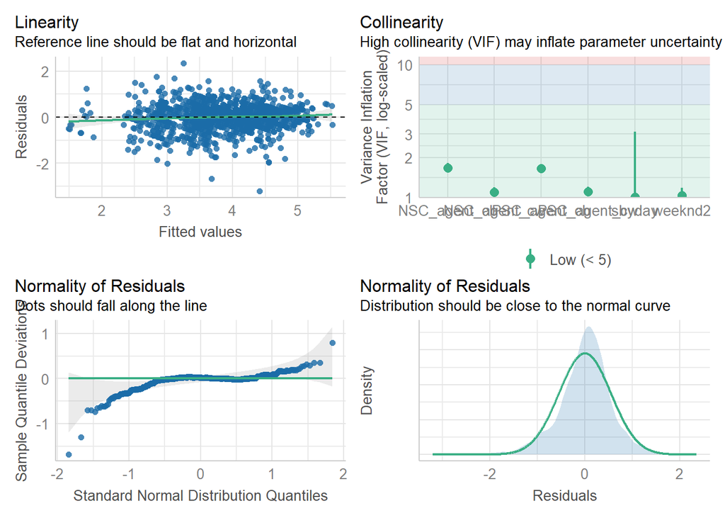

```r
posaff_target_rep <- full_report(posaff_target, order_rep)


# prepare to save to excel
all_models <- list(posaff_target_rep = posaff_target_rep)
```

#### Negative Affect - Target

Due to convergence Issue, AR1 had to be replaced with an unstructured error covariance matrix.

```r
### Base model for negative affect target
negaff_target <- lme(
  fixed = Naff_target ~
        PSC_agent_cw + NSC_agent_cw +
        sbyday + weeknd2 +
        PSC_agent_cb + NSC_agent_cb,
  data = as.data.frame(df),
  random = ~ PSC_agent_cw + NSC_agent_cw | CoupleID,
  #correlation = corAR1(form = ~ 1 | CoupleID),
  na.action = na.omit,
  control = lmeControl(opt='optim',
                         maxIter = 1e4,
                         msMaxEval = 1e4)
)

check_singularity(negaff_target)
```

```
## [1] FALSE
```

```r
performance::check_model(negaff_target)
```

```
## Converting missing values (`NA`) into regular values currently not
##   possible for variables of class `NULL`.
```

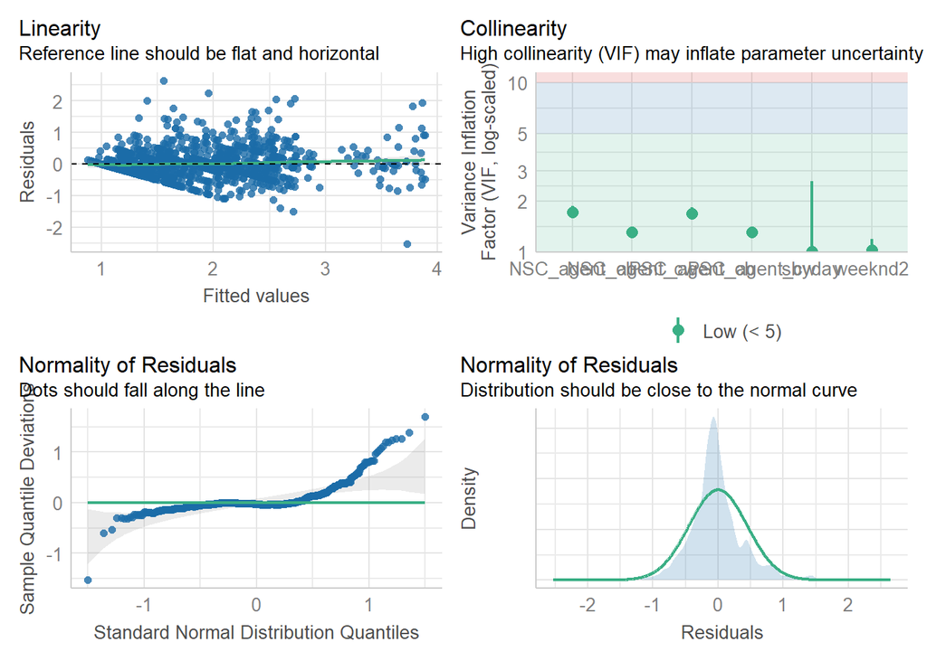

```r
negaff_target_rep <- full_report(negaff_target, order=order_rep)
negaff_target_rep
```

|  | Parameter | Coefficient | SE | p | CI_low | CI_high | Effects |
| --- | --- | --- | --- | --- | --- | --- | --- |
| 1 | (Intercept) | 1.83*** | 0.07 | 0.000 | 1.69 | 1.96 | fixed |
| 16 | —WITHIN-PERSON EFFECTS— | NA | NA | NA | NA | NA | NA |
| 2 | PSC_agent_cw | 0.02 | 0.05 | 0.774 | -0.09 | 0.12 | fixed |
| 3 | NSC_agent_cw | -0.09 | 0.09 | 0.280 | -0.26 | 0.08 | fixed |
| 4 | sbyday | 0.00 | 0.00 | 0.299 | 0.00 | 0.01 | fixed |
| 5 | weeknd2 | -0.12*** | 0.03 | 0.000 | -0.18 | -0.06 | fixed |
| NA | NA | NA | NA | NA | NA | NA | NA |
| 17 | —BETWEEN-PERSON EFFECTS— | NA | NA | NA | NA | NA | NA |
| 6 | PSC_agent_cb | -0.36 | 0.22 | 0.107 | -0.80 | 0.08 | fixed |
| 7 | NSC_agent_cb | 0.50 | 0.42 | 0.241 | -0.34 | 1.33 | fixed |
| NA.1 | NA | NA | NA | NA | NA | NA | NA |
| 18 | —RANDOM-EFFECTS— | NA | NA | NA | NA | NA | NA |
| 8 | Std.Dev.(Intercept)\|CoupleID | 0.63 | NA | NA | 0.54 | 0.73 | random |
| 9 | Std.Dev.PSC_agent_cw\|CoupleID | 0.26 | NA | NA | 0.16 | 0.42 | random |
| 10 | Std.Dev.NSC_agent_cw\|CoupleID | 0.27 | NA | NA | 0.10 | 0.67 | random |
| 11 | Cor.PSC_agent_cw.(Intercept)\|CoupleID | -0.40 | NA | NA | -0.70 | 0.03 | random |
| 12 | Cor.NSC_agent_cw.(Intercept)\|CoupleID | -0.13 | NA | NA | -0.63 | 0.45 | random |
| 13 | Cor.NSC_agent_cw.PSC_agent_cw\|CoupleID | -0.84 | NA | NA | -0.99 | 0.36 | random |
| 19 | ———MODEL INFO——— | NA | NA | NA | NA | NA | NA |
| 15 | Within-group standard error | 0.47 | NA | NA | 0.45 | 0.49 | random |
| 20 | dispersion | NA | NA | NA | NA | NA | NA |
| 14 | AR1 | NA | NA | NA | NA | NA | random |

```r
# Add to list
all_models[['negaff_target_rep']] <- negaff_target_rep
```

#### MVPA - Target

```r
mean(df$sbwmvpa01, na.rm=T)
```

```
## [1] 48.7621
```

```r
var(df$sbwmvpa01, na.rm=T)
```

```
## [1] 1439.086
```

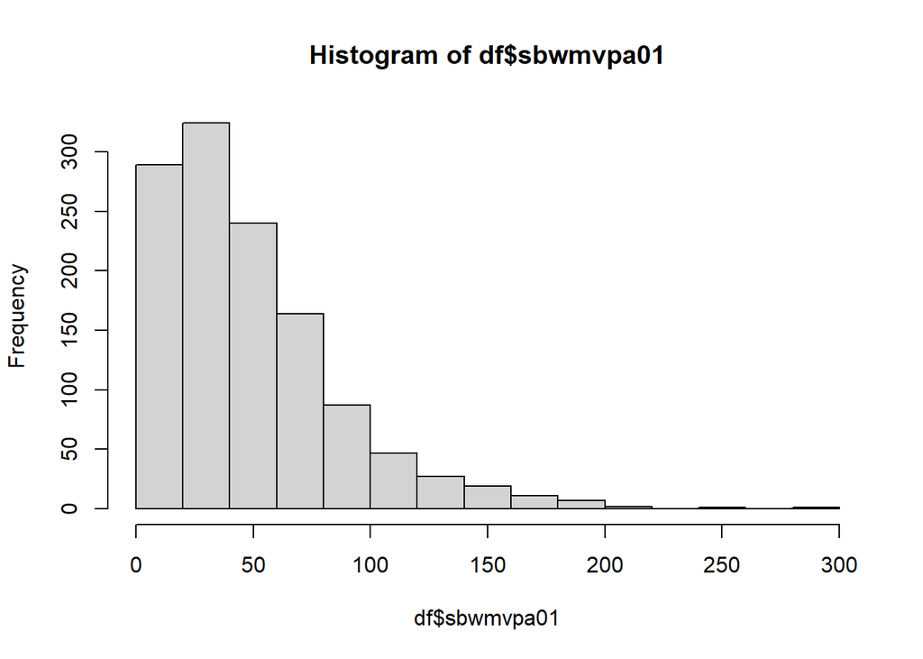

```r
hist(df$sbwmvpa01)
```

Due to the distribution of the data, a poisson-regression was considered. However, the data seems to be overdispersed (variance greater than mean). Therefore, a quasi-poisson modelling approach was selected to model the overdispersion.

```r
mvpa_target <- glmmTMB(
  sbwmvpa01 ~
    PSC_agent_cw + NSC_agent_cw +
    sbyday + weeknd2 +
    PSC_agent_cb + NSC_agent_cb +
    sbwwear_cw + sbwwear_cb +

    (1 + PSC_agent_cw + NSC_agent_cw | CoupleID) +
    ar1(factor(sbyday) - 1 | CoupleID),
    family = nbinom1,
    data = df,
    control = glmmTMBControl(optArgs = list(iter.max = 1e4, eval.max = 1e4))
)
check_singularity(mvpa_target)
```

```
## [1] FALSE
```

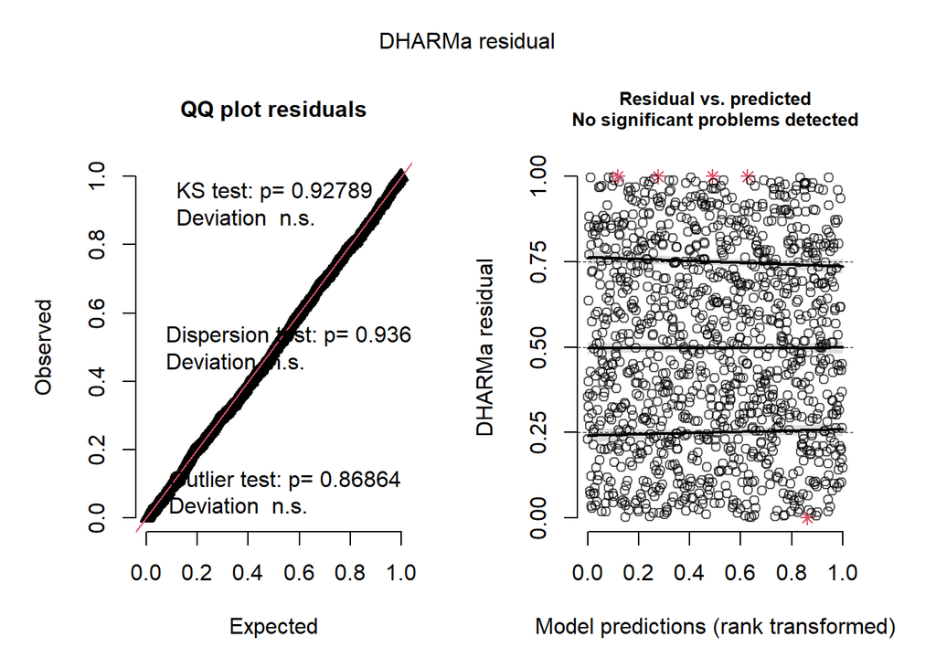

```r
simResids <- simulateResiduals(mvpa_target, nSim=1005)
plot(simResids)
```

```r
mvpa_target_rep <- full_report(mvpa_target, order_rep)
mvpa_target_rep
```

|  | Parameter | Coefficient | SE | p | CI_low | CI_high | Effects | Component |
| --- | --- | --- | --- | --- | --- | --- | --- | --- |
| 1 | (Intercept) | 41.72*** | 2.55 | 0.000 | 37.00 | 47.04 | fixed | conditional |
| 17 | —WITHIN-PERSON EFFECTS— | NA | NA | NA | NA | NA | NA | NA |
| 2 | PSC_agent_cw | 1.37*** | 0.08 | 0.000 | 1.22 | 1.54 | fixed | conditional |
| 3 | NSC_agent_cw | 0.82 | 0.09 | 0.058 | 0.67 | 1.01 | fixed | conditional |
| 4 | sbyday | 1.00 | 0.00 | 0.266 | 1.00 | 1.01 | fixed | conditional |
| 5 | weeknd2 | 0.87*** | 0.03 | 0.000 | 0.80 | 0.94 | fixed | conditional |
| 8 | weartime_cw | 1.05*** | 0.01 | 0.000 | 1.03 | 1.07 | fixed | conditional |
| 18 | —BETWEEN-PERSON EFFECTS— | NA | NA | NA | NA | NA | NA | NA |
| 6 | PSC_agent_cb | 1.02 | 0.18 | 0.894 | 0.72 | 1.45 | fixed | conditional |
| 7 | NSC_agent_cb | 1.24 | 0.43 | 0.540 | 0.63 | 2.44 | fixed | conditional |
| 9 | weartime_cb | 1.06* | 0.03 | 0.046 | 1.00 | 1.12 | fixed | conditional |
| 19 | —RANDOM-EFFECTS— | NA | NA | NA | NA | NA | NA | NA |
| 11 | Std.Dev.(Intercept)\|CoupleID | 0.43 | NA | NA | 0.20 | 0.97 | random | conditional |
| 12 | Std.Dev.PSC_agent_cw\|CoupleID | 0.18 | NA | NA | 0.06 | 0.52 | random | conditional |
| 13 | Std.Dev.NSC_agent_cw\|CoupleID | 0.12 | NA | NA | 0.01 | 1.02 | random | conditional |
| 14 | Cor.PSC_agent_cw.(Intercept)\|CoupleID | -0.57 | NA | NA | -0.92 | 0.66 | random | conditional |
| 15 | Cor.NSC_agent_cw.(Intercept)\|CoupleID | -0.99 | NA | NA | -0.98 | 0.98 | random | conditional |
| 16 | Cor.NSC_agent_cw.PSC_agent_cw\|CoupleID | 0.55 | NA | NA | 0.80 | 0.82 | random | conditional |
| 21 | ———MODEL INFO——— | NA | NA | NA | NA | NA | NA | NA |
| 20 | Within-group standard error | NA | NA | NA | NA | NA | NA | NA |
| 10 | dispersion | 14.40 | NA | NA | 12.92 | 16.06 | fixed | dispersion |
| 22 | AR1 | 0.97 | NA | NA | NA | NA | NA | NA |

```r
# extend list

all_models[['mvpa_target_rep']] <- mvpa_target_rep
```

Note, that fixed effects and their CI have been exponentiated, representing now odds ratios. SE have been scaled. Random effects are still on the log-scale and represent the variability.

### Models for AGENT

How is the use of persuasion and pressure associated with outcomes in the user?

#### Positive affect - Agent

```r
posaff_agent <- lme(
  fixed = Paff_agent ~
        PSC_agent_cw + NSC_agent_cw +
        sbyday + weeknd2 +
        PSC_agent_cb + NSC_agent_cb,
  data = as.data.frame(df),
  random = ~ NSC_agent_cw + PSC_agent_cw | CoupleID,
  correlation = corAR1(form = ~ 1 | CoupleID),
  na.action = na.omit,
  control = lmeControl(opt='optim',
                      maxIter = 1e4,
                      msMaxEval = 1e4)
)
check_singularity(posaff_agent)
```

```
## [1] FALSE
```

```r
performance::check_model(posaff_agent)
```

```
## Converting missing values (`NA`) into regular values currently not
##   possible for variables of class `NULL`.
```

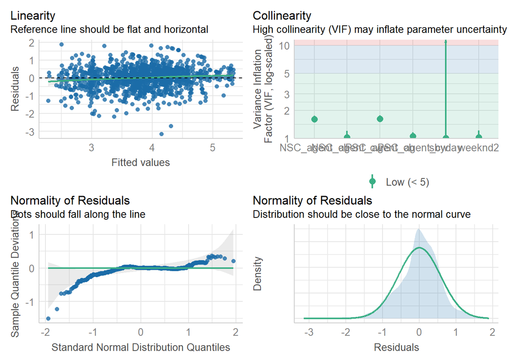

```r
posaff_agent_rep <- full_report(posaff_agent,order=order_rep)
posaff_agent_rep
```

|  | Parameter | Coefficient | SE | p | CI_low | CI_high | Effects |
| --- | --- | --- | --- | --- | --- | --- | --- |
| 1 | (Intercept) | 3.83*** | 0.08 | 0.000 | 3.68 | 3.98 | fixed |
| 16 | —WITHIN-PERSON EFFECTS— | NA | NA | NA | NA | NA | NA |
| 2 | PSC_agent_cw | 0.33*** | 0.06 | 0.000 | 0.21 | 0.45 | fixed |
| 3 | NSC_agent_cw | -0.28* | 0.12 | 0.021 | -0.51 | -0.04 | fixed |
| 4 | sbyday | -0.00 | 0.00 | 0.596 | -0.01 | 0.01 | fixed |
| 5 | weeknd2 | 0.04 | 0.04 | 0.254 | -0.03 | 0.12 | fixed |
| NA | NA | NA | NA | NA | NA | NA | NA |
| 17 | —BETWEEN-PERSON EFFECTS— | NA | NA | NA | NA | NA | NA |
| 6 | PSC_agent_cb | 0.13 | 0.23 | 0.576 | -0.33 | 0.60 | fixed |
| 7 | NSC_agent_cb | 0.16 | 0.45 | 0.717 | -0.73 | 1.06 | fixed |
| NA.1 | NA | NA | NA | NA | NA | NA | NA |
| 18 | —RANDOM-EFFECTS— | NA | NA | NA | NA | NA | NA |
| 8 | Std.Dev.(Intercept)\|CoupleID | 0.64 | NA | NA | 0.55 | 0.75 | random |
| 10 | Std.Dev.PSC_agent_cw\|CoupleID | 0.24 | NA | NA | 0.12 | 0.49 | random |
| 9 | Std.Dev.NSC_agent_cw\|CoupleID | 0.33 | NA | NA | 0.12 | 0.92 | random |
| 12 | Cor.PSC_agent_cw.(Intercept)\|CoupleID | -0.47 | NA | NA | -0.86 | 0.27 | random |
| 11 | Cor.NSC_agent_cw.(Intercept)\|CoupleID | 0.27 | NA | NA | -0.62 | 0.86 | random |
| 13 | Cor.NSC_agent_cw.PSC_agent_cw\|CoupleID | 0.54 | NA | NA | -0.90 | 0.99 | random |
| 19 | ———MODEL INFO——— | NA | NA | NA | NA | NA | NA |
| 15 | Within-group standard error | 0.61 | NA | NA | 0.59 | 0.64 | random |
| 20 | dispersion | NA | NA | NA | NA | NA | NA |
| 14 | AR1 | 0.19 | NA | NA | 0.13 | 0.26 | random |

```r
# Add to list

all_models[['posaff_agent_rep']] <- posaff_agent_rep
```

#### Negative Affect - Agent

Ar1 had to be removed to achieve convergence.

```r
### Base model for negative affect target
# Specifying model for Negative Affect
negaff_agent <- lme(
  fixed = Naff_agent ~
        PSC_agent_cw + NSC_agent_cw +
        sbyday + weeknd2 +
        PSC_agent_cb + NSC_agent_cb,
  data = as.data.frame(df),
  random = ~ PSC_agent_cw + NSC_agent_cw | CoupleID,
  #correlation = corAR1(form = ~ 1 | CoupleID),
  na.action = na.omit,
  control = lmeControl(opt='optim',
                         maxIter = 1e4,
                         msMaxEval = 1e4)
)
check_singularity(negaff_agent)
```

```
## [1] FALSE
```

```r
performance::check_model(negaff_agent)
```

```
## Converting missing values (`NA`) into regular values currently not
##   possible for variables of class `NULL`.
```

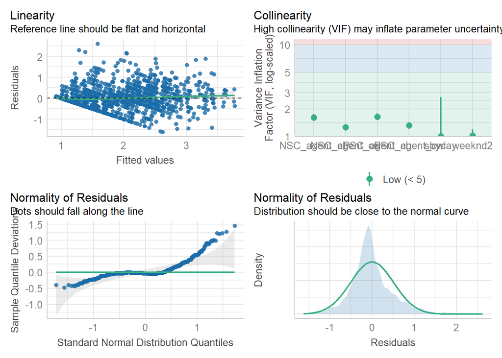

```r
negaff_agent_rep <- full_report(negaff_agent,order=order_rep)
negaff_agent_rep
```

|  | Parameter | Coefficient | SE | p | CI_low | CI_high | Effects |
| --- | --- | --- | --- | --- | --- | --- | --- |
| 1 | (Intercept) | 1.94*** | 0.07 | 0.000 | 1.80 | 2.07 | fixed |
| 16 | —WITHIN-PERSON EFFECTS— | NA | NA | NA | NA | NA | NA |
| 2 | PSC_agent_cw | -0.16** | 0.06 | 0.008 | -0.28 | -0.04 | fixed |
| 3 | NSC_agent_cw | 0.22* | 0.09 | 0.016 | 0.04 | 0.39 | fixed |
| 4 | sbyday | 0.00 | 0.00 | 0.456 | 0.00 | 0.01 | fixed |
| 5 | weeknd2 | -0.15*** | 0.03 | 0.000 | -0.22 | -0.09 | fixed |
| NA | NA | NA | NA | NA | NA | NA | NA |
| 17 | —BETWEEN-PERSON EFFECTS— | NA | NA | NA | NA | NA | NA |
| 6 | PSC_agent_cb | 0.32 | 0.22 | 0.146 | -0.11 | 0.75 | fixed |
| 7 | NSC_agent_cb | 0.09 | 0.42 | 0.825 | -0.73 | 0.92 | fixed |
| NA.1 | NA | NA | NA | NA | NA | NA | NA |
| 18 | —RANDOM-EFFECTS— | NA | NA | NA | NA | NA | NA |
| 8 | Std.Dev.(Intercept)\|CoupleID | 0.62 | NA | NA | 0.54 | 0.72 | random |
| 9 | Std.Dev.PSC_agent_cw\|CoupleID | 0.27 | NA | NA | 0.17 | 0.44 | random |
| 10 | Std.Dev.NSC_agent_cw\|CoupleID | 0.23 | NA | NA | 0.08 | 0.68 | random |
| 11 | Cor.PSC_agent_cw.(Intercept)\|CoupleID | -0.60 | NA | NA | -0.87 | -0.05 | random |
| 12 | Cor.NSC_agent_cw.(Intercept)\|CoupleID | 0.59 | NA | NA | -0.73 | 0.98 | random |
| 13 | Cor.NSC_agent_cw.PSC_agent_cw\|CoupleID | -0.98 | NA | NA | -1.00 | 1.00 | random |
| 19 | ———MODEL INFO——— | NA | NA | NA | NA | NA | NA |
| 15 | Within-group standard error | 0.54 | NA | NA | 0.51 | 0.56 | random |
| 20 | dispersion | NA | NA | NA | NA | NA | NA |
| 14 | AR1 | NA | NA | NA | NA | NA | random |

```r
# Add to list

all_models[['negaff_agent_rep']] <- negaff_agent_rep
```

#### MVPA - Agent

```r
mean(df$pbwmvpa01, na.rm=T)
```

```
## [1] 47.47229
```

```r
var(df$pbwmvpa01, na.rm=T)
```

```
## [1] 1318.667
```

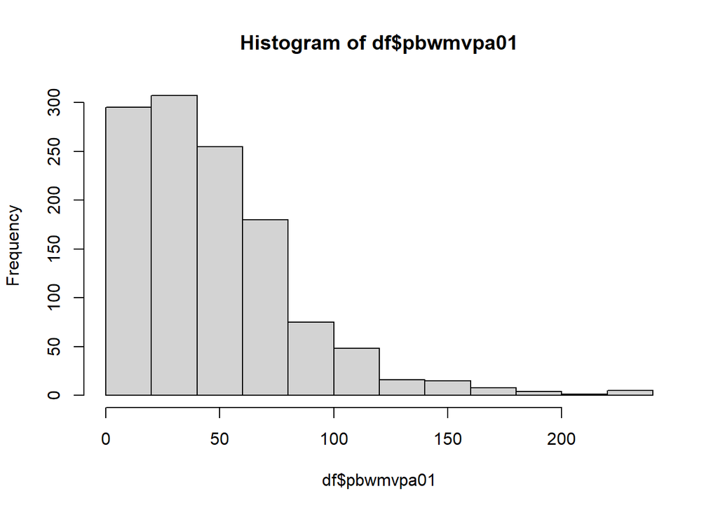

```r
hist(df$pbwmvpa01)
```

Due to the distribution of the data, a poisson-regression was considered. However, the data seems to be overdispersed (variance greater than mean). Therefore, a quasi-poisson modelling approach was selected to model the overdispersion.

Did not converge. Our preferred alternative (no AR1) does not converge either. We select the next best model, which drops both the AR1 term, as well as the random slope for NSC, which was zero.

```r
# Base Model (not converging)
mvpa_partner <- glmmTMB(
    pbwmvpa01 ~
      PSC_agent_cw + NSC_agent_cw +
      sbyday + weeknd2 +
      PSC_agent_cb + NSC_agent_cb +
      pbwwear_cw + pbwwear_cb +
      (1 + PSC_agent_cw | CoupleID),
    family = nbinom1,
    data = df,
    control = glmmTMBControl(optimizer = nlminb,
                             optArgs = list(iter.max = 1e4,
                                            eval.max = 1e4))
)
check_singularity(mvpa_partner)
```

```
## [1] FALSE
```

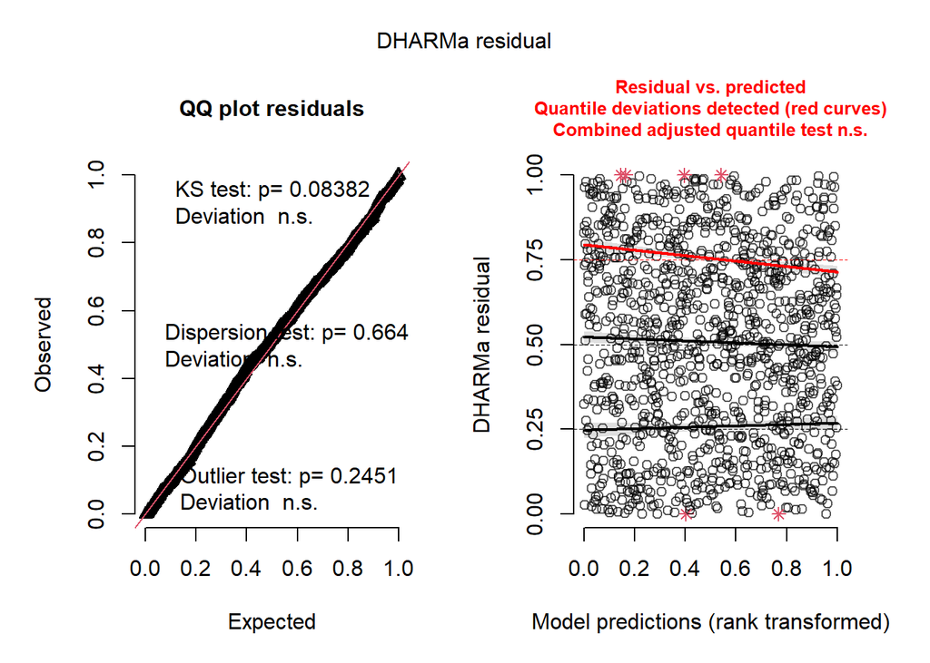

```r
simResids <- simulateResiduals(mvpa_partner, nSim = 1005)
plot(simResids)
```

```r
mvpa_agent_rep <- full_report(mvpa_partner, order= order_rep)
mvpa_agent_rep
```

|  | Parameter | Coefficient | SE | p | CI_low | CI_high | Effects | Component |
| --- | --- | --- | --- | --- | --- | --- | --- | --- |
| 1 | (Intercept) | 44.13*** | 2.67 | 0.000 | 39.20 | 49.67 | fixed | conditional |
| 14 | —WITHIN-PERSON EFFECTS— | NA | NA | NA | NA | NA | NA | NA |
| 2 | PSC_agent_cw | 1.19* | 0.09 | 0.016 | 1.03 | 1.37 | fixed | conditional |
| 3 | NSC_agent_cw | 1.08 | 0.11 | 0.473 | 0.88 | 1.33 | fixed | conditional |
| 4 | sbyday | 1.00 | 0.00 | 0.283 | 0.99 | 1.00 | fixed | conditional |
| 5 | weeknd2 | 0.90* | 0.04 | 0.010 | 0.83 | 0.97 | fixed | conditional |
| 8 | weartime_cw | 1.03** | 0.01 | 0.002 | 1.01 | 1.06 | fixed | conditional |
| 15 | —BETWEEN-PERSON EFFECTS— | NA | NA | NA | NA | NA | NA | NA |
| 6 | PSC_agent_cb | 0.75 | 0.13 | 0.106 | 0.53 | 1.06 | fixed | conditional |
| 7 | NSC_agent_cb | 1.83 | 0.67 | 0.099 | 0.89 | 3.75 | fixed | conditional |
| 9 | weartime_cb | 0.99 | 0.03 | 0.826 | 0.94 | 1.05 | fixed | conditional |
| 16 | —RANDOM-EFFECTS— | NA | NA | NA | NA | NA | NA | NA |
| 11 | Std.Dev.(Intercept)\|CoupleID | 0.47 | NA | NA | 0.40 | 0.56 | random | conditional |
| 12 | Std.Dev.PSC_agent_cw\|CoupleID | 0.27 | NA | NA | 0.16 | 0.45 | random | conditional |
| NA | NA | NA | NA | NA | NA | NA | NA | NA |
| 13 | Cor.PSC_agent_cw.(Intercept)\|CoupleID | 0.29 | NA | NA | -0.26 | 0.66 | random | conditional |
| NA.1 | NA | NA | NA | NA | NA | NA | NA | NA |
| NA.2 | NA | NA | NA | NA | NA | NA | NA | NA |
| 18 | ———MODEL INFO——— | NA | NA | NA | NA | NA | NA | NA |
| 17 | Within-group standard error | NA | NA | NA | NA | NA | NA | NA |
| 10 | dispersion | 15.31 | NA | NA | 13.88 | 16.89 | fixed | dispersion |
| 19 | AR1 | NA | NA | NA | NA | NA | NA | NA |

```r
# Add to list
all_models[['mvpa_agent_rep']] <- mvpa_agent_rep
```

Note, that fixed effects and their CIs have been exponentiated, representing now odds ratios. SE have been scaled. Random effects are still on the log-scale and represent the variability.

```r
# Save list to file
#writexl::write_xlsx(all_models, "All_Models.xlsx")
```

# Report everything again side by side for a cleaner appearance.

## FUNCTION TO REPORT EVERYTHING SIDE BY SIDE

```r
report_side_by_side <- function(models, order, model_names) {

  if (length(models) != length(model_names)) {
    stop('Number of models must match number of model names.')
  }

  report_finished <- NULL
  for (i in 1:length(models)) {
    rep <- full_report(models[[i]], order)

    rownames(rep) <- order

    rep$CI <- ifelse(is.na(rep$CI_low), NA,
      paste0('[', rep$CI_low, ', ', rep$CI_high, ']')
    )

    rep <- rep[ , c('Coefficient', 'CI')]


    colnames(rep) <- paste(colnames(rep), model_names[i])
    rep

    #in the first round, we keep the column with the names to the left.
    if (i == 1) {
      rep$Parameter <- rownames(rep)
      rep <- rep[, c(3, 1,2)]
    }


    # Combine
    if (is.null(report_finished)) {
      report_finished <- rep
    } else {
      report_finished <- cbind(report_finished, rep)
    }
  }

  rownames(report_finished) <- NULL

  return(report_finished)
}
```

## Rerport all Main Models Side by Side

```r
export_everything <- list()

base_models <- report_side_by_side(
  models = list(
    posaff_agent, posaff_target,
    negaff_agent, negaff_target,
    mvpa_partner, mvpa_target
  ),
  order <- order_rep,
  model_names = list(
    'Posaff Agent', 'Posaff Target',
    'Negaff Agent', 'Negaff Target',
    'MVPA Agent', 'MVPA Target'
  )
)

base_models
```

| Parameter | Coefficient Posaff Agent | CI Posaff Agent | Coefficient Posaff Target | CI Posaff Target | Coefficient Negaff Agent | CI Negaff Agent | Coefficient Negaff Target | CI Negaff Target | Coefficient MVPA Agent | CI MVPA Agent | Coefficient MVPA Target | CI MVPA Target |
| --- | --- | --- | --- | --- | --- | --- | --- | --- | --- | --- | --- | --- |
| (Intercept) | 3.83*** | [3.68, 3.98] | 3.98*** | [3.82, 4.14] | 1.94*** | [1.8, 2.07] | 1.83*** | [1.69, 1.96] | 44.13*** | [39.2, 49.67] | 41.72*** | [37, 47.04] |
| —WITHIN-PERSON EFFECTS— | NA | NA | NA | NA | NA | NA | NA | NA | NA | NA | NA | NA |
| PSC_agent_cw | 0.33*** | [0.21, 0.45] | 0.01 | [-0.11, 0.13] | -0.16** | [-0.28, -0.04] | 0.02 | [-0.09, 0.12] | 1.19* | [1.03, 1.37] | 1.37*** | [1.22, 1.54] |
| NSC_agent_cw | -0.28* | [-0.51, -0.04] | -0.01 | [-0.21, 0.2] | 0.22* | [0.04, 0.39] | -0.09 | [-0.26, 0.08] | 1.08 | [0.88, 1.33] | 0.82 | [0.67, 1.01] |
| sbyday | -0.00 | [-0.01, 0.01] | -0.01** | [-0.02, -0.01] | 0.00 | [0, 0.01] | 0.00 | [0, 0.01] | 1.00 | [0.99, 1] | 1.00 | [1, 1.01] |
| weeknd2 | 0.04 | [-0.03, 0.12] | 0.04 | [-0.03, 0.11] | -0.15*** | [-0.22, -0.09] | -0.12*** | [-0.18, -0.06] | 0.90* | [0.83, 0.97] | 0.87*** | [0.8, 0.94] |
| weartime_cw | NA | NA | NA | NA | NA | NA | NA | NA | 1.03** | [1.01, 1.06] | 1.05*** | [1.03, 1.07] |
| —BETWEEN-PERSON EFFECTS— | NA | NA | NA | NA | NA | NA | NA | NA | NA | NA | NA | NA |
| PSC_agent_cb | 0.13 | [-0.33, 0.6] | 0.36 | [-0.14, 0.87] | 0.32 | [-0.11, 0.75] | -0.36 | [-0.8, 0.08] | 0.75 | [0.53, 1.06] | 1.02 | [0.72, 1.45] |
| NSC_agent_cb | 0.16 | [-0.73, 1.06] | -0.73 | [-1.7, 0.25] | 0.09 | [-0.73, 0.92] | 0.50 | [-0.34, 1.33] | 1.83 | [0.89, 3.75] | 1.24 | [0.63, 2.44] |
| weartime_cb | NA | NA | NA | NA | NA | NA | NA | NA | 0.99 | [0.94, 1.05] | 1.06* | [1, 1.12] |
| —RANDOM-EFFECTS— | NA | NA | NA | NA | NA | NA | NA | NA | NA | NA | NA | NA |
| Std.Dev.(Intercept)\|CoupleID | 0.64 | [0.55, 0.75] | 0.72 | [0.62, 0.83] | 0.62 | [0.54, 0.72] | 0.63 | [0.54, 0.73] | 0.47 | [0.4, 0.56] | 0.43 | [0.2, 0.97] |
| Std.Dev.PSC_agent_cw\|CoupleID | 0.24 | [0.12, 0.49] | 0.20 | [0.08, 0.5] | 0.27 | [0.17, 0.44] | 0.26 | [0.16, 0.42] | 0.27 | [0.16, 0.45] | 0.18 | [0.06, 0.52] |
| Std.Dev.NSC_agent_cw\|CoupleID | 0.33 | [0.12, 0.92] | 0.15 | [0.02, 1.29] | 0.23 | [0.08, 0.68] | 0.27 | [0.1, 0.67] | NA | NA | 0.12 | [0.01, 1.02] |
| Cor.PSC_agent_cw.(Intercept)\|CoupleID | -0.47 | [-0.86, 0.27] | -0.44 | [-0.88, 0.4] | -0.60 | [-0.87, -0.05] | -0.40 | [-0.7, 0.03] | 0.29 | [-0.26, 0.66] | -0.57 | [-0.92, 0.66] |
| Cor.NSC_agent_cw.(Intercept)\|CoupleID | 0.27 | [-0.62, 0.86] | -0.57 | [-0.99, 0.87] | 0.59 | [-0.73, 0.98] | -0.13 | [-0.63, 0.45] | NA | NA | -0.99 | [-0.98, 0.98] |
| Cor.NSC_agent_cw.PSC_agent_cw\|CoupleID | 0.54 | [-0.9, 0.99] | 0.83 | [-1, 1] | -0.98 | [-1, 1] | -0.84 | [-0.99, 0.36] | NA | NA | 0.55 | [0.8, 0.82] |
| ———MODEL INFO——— | NA | NA | NA | NA | NA | NA | NA | NA | NA | NA | NA | NA |
| Within-group standard error | 0.61 | [0.59, 0.64] | 0.57 | [0.55, 0.6] | 0.54 | [0.51, 0.56] | 0.47 | [0.45, 0.49] | NA | NA | NA | NA |
| dispersion | NA | NA | NA | NA | NA | NA | NA | NA | 15.31 | [13.88, 16.89] | 14.40 | [12.92, 16.06] |
| AR1 | 0.19 | [0.13, 0.26] | NA | NA | NA | NA | NA | NA | NA | NA | 0.97 | NA |

```r
export_everything$Base_Models <- base_models
```

```r
mvpa_target_original <- mvpa_target
```

# Sensitivity Analyses

Between person variables - Between Centred Social Support (Sup_agent_cb, Sup_target_cb) - Between Centred Time Spent Together (time_spent_cb) - Experimental Groups (group) - Relationship Duration (reldur) - Age (sage, page) - BMI (sbmi, pbmi) - sex (sb0sex01, pb0sex01) - children (sb0kih01)

Within-person variables - Sup_agent_cw, sup_target_cw - time_spent_cw

## Introcuding ALL control variables

### Positive Affect - Target

```r
posaff_target <- lme(
    fixed = Paff_target~
        PSC_agent_cw + NSC_agent_cw +
        sbyday + weeknd2 +
        PSC_agent_cb + NSC_agent_cb +

      # Between covariates
      Sup_agent_cb +Sup_target_cb +
      time_spent_cb +
      group +
      reldur_cb +
      sage +
      sbmi +
      sb0sex01 +
      sb0kih01 +

      # individual covariates agent Within
      #intention_agent_lagged_cw +
      #self_efficacy_agent_lagged_cw +
      #plan_agent_lagged_cw +
      #risk_perception_agent_cw +
      #perceived_benfeits_agent_cw +
      # individual covariates target Within
      #intention_target_lagged_cw +
      #self_efficacy_target_lagged_cw +
      #plan_target_lagged_cw +
      #risk_perception_target_cw +
      #perceived_benfeits_target_cw +

      # individual covariates agent Between
      #intention_agent_lagged_cb +
      #self_efficacy_agent_lagged_cb +
      #plan_agent_lagged_cb +
      #risk_perception_agent_cb +
      #perceived_benfeits_agent_cb +
      # individual covariates target Between
      #intention_target_lagged_cb +
      #self_efficacy_target_lagged_cb +
      #plan_target_lagged_cb +
      #risk_perception_target_cb +
      #perceived_benfeits_target_cb +

      # Support
      Sup_agent_cw + Sup_target_cw + time_spent_cw,
    data = as.data.frame(df),
    random = ~ PSC_agent_cw + NSC_agent_cw | CoupleID,
    #correlation = corAR1(form = ~ 1 | CoupleID),
    na.action = na.omit,
    control = lmeControl(opt='optim',
                         maxIter = 1e4,
                         msMaxEval = 1e4)
)

check_singularity(posaff_target)
```

```
## [1] FALSE
```

### Negative Affect - Target

```r
negaff_target <- lme(
  fixed = Naff_target ~
        PSC_agent_cw + NSC_agent_cw +
        sbyday + weeknd2 +
        PSC_agent_cb + NSC_agent_cb +
    # Between covariates
      Sup_agent_cb +Sup_target_cb +
      time_spent_cb +
      group +
      reldur_cb +
      sage +
      sbmi +
      sb0sex01 +
      sb0kih01 +

      # individual covariates agent Within
      #intention_agent_lagged_cw +
      #self_efficacy_agent_lagged_cw +
      #plan_agent_lagged_cw +
      #risk_perception_agent_cw +
      #perceived_benfeits_agent_cw +
      # individual covariates target Within
      #intention_target_lagged_cw +
      #self_efficacy_target_lagged_cw +
      #plan_target_lagged_cw +
      #risk_perception_target_cw +
      #perceived_benfeits_target_cw +

      # individual covariates agent Between
      #intention_agent_lagged_cb +
      #self_efficacy_agent_lagged_cb +
      #plan_agent_lagged_cb +
      #risk_perception_agent_cb +
      #perceived_benfeits_agent_cb +
      # individual covariates target Between
      #intention_target_lagged_cb +
      #self_efficacy_target_lagged_cb +
      #plan_target_lagged_cb +
      #risk_perception_target_cb +
      #perceived_benfeits_target_cb +

      # Support
      Sup_agent_cw + Sup_target_cw + time_spent_cw,

  data = as.data.frame(df),
  random = ~ PSC_agent_cw + NSC_agent_cw | CoupleID,
  #correlation = corAR1(form = ~ 1 | CoupleID),
  na.action = na.omit,
  control = lmeControl(opt='optim',
                         maxIter = 1e4,
                         msMaxEval = 1e4)
)

check_singularity(negaff_target)
```

```
## [1] FALSE
```

### MVPA - Target

```r
mvpa_target <- glmmTMB(
  sbwmvpa01 ~
    PSC_agent_cw + NSC_agent_cw +
    sbyday + weeknd2 +
    PSC_agent_cb + NSC_agent_cb +
    sbwwear_cw + sbwwear_cb +

    # Between covariates
      Sup_agent_cb +Sup_target_cb +
      time_spent_cb +
      group +
      reldur_cb +
      sage +
      sbmi +
      sb0sex01 +
      sb0kih01 +

      # individual covariates agent Within
      intention_agent_lagged_cw +
      self_efficacy_agent_lagged_cw +
      plan_agent_lagged_cw +
      risk_perception_agent_cw +
      perceived_benfeits_agent_cw +
      # individual covariates target Within
      intention_target_lagged_cw +
      self_efficacy_target_lagged_cw +
      plan_target_lagged_cw +
      risk_perception_target_cw +
      perceived_benfeits_target_cw +

      # individual covariates agent Between
      intention_agent_lagged_cb +
      self_efficacy_agent_lagged_cb +
      plan_agent_lagged_cb +
      risk_perception_agent_cb +
      perceived_benfeits_agent_cb +
      # individual covariates target Between
      intention_target_lagged_cb +
      self_efficacy_target_lagged_cb +
      plan_target_lagged_cb +
      risk_perception_target_cb +
      perceived_benfeits_target_cb +

      # Support
      Sup_agent_cw + Sup_target_cw + time_spent_cw +

    (1 | CoupleID),
    family = nbinom1,
    data = df,
    control = glmmTMBControl(optArgs = list(iter.max = 1e4, eval.max = 1e4))
)
check_singularity(mvpa_target)
```

```
## [1] FALSE
```

```r
# get the p-value for our paper
a <- summary(mvpa_target)
round(a$coefficients$cond['NSC_agent_cw', 4], 3)
```

```
## [1] 0.015
```

### Positive affect - Agent

```r
posaff_agent <- lme(
  fixed = Paff_agent ~
        PSC_agent_cw + NSC_agent_cw +
        sbyday + weeknd2 +
        PSC_agent_cb + NSC_agent_cb +
    # Between covariates
      Sup_agent_cb +Sup_target_cb +
      time_spent_cb +
      group +
      reldur_cb +
      page +
      pbmi +
      pb0sex01 +
      pb0kih01 +

      # individual covariates agent Within
      #intention_agent_lagged_cw +
      #self_efficacy_agent_lagged_cw +
      #plan_agent_lagged_cw +
      #risk_perception_agent_cw +
      #perceived_benfeits_agent_cw +
      # individual covariates target Within
      #intention_target_lagged_cw +
      #self_efficacy_target_lagged_cw +
      #plan_target_lagged_cw +
      #risk_perception_target_cw +
      #perceived_benfeits_target_cw +

      # individual covariates agent Between
      #intention_agent_lagged_cb +
      #self_efficacy_agent_lagged_cb +
      #plan_agent_lagged_cb +
      #risk_perception_agent_cb +
      #perceived_benfeits_agent_cb +
      # individual covariates target Between
      #intention_target_lagged_cb +
      #self_efficacy_target_lagged_cb +
      #plan_target_lagged_cb +
      #risk_perception_target_cb +
      #perceived_benfeits_target_cb +

      # Support
      Sup_agent_cw + Sup_target_cw + time_spent_cw,

  data = as.data.frame(df),
  random = ~ NSC_agent_cw + PSC_agent_cw | CoupleID,
  correlation = corAR1(form = ~ 1 | CoupleID),
  na.action = na.omit,
  control = lmeControl(opt='optim',
                      maxIter = 1e4,
                      msMaxEval = 1e4)
)
check_singularity(posaff_agent)
```

```
## [1] FALSE
```

### Negative Affect - Agent

```r
negaff_agent <- lme(
  fixed = Naff_agent ~
        PSC_agent_cw + NSC_agent_cw +
        sbyday + weeknd2 +
        PSC_agent_cb + NSC_agent_cb +
    # Between covariates
      Sup_agent_cb +Sup_target_cb +
      time_spent_cb +
      group +
      reldur_cb +
      page +
      pbmi +
      pb0sex01 +
      pb0kih01 +

      # individual covariates agent Within
      #intention_agent_lagged_cw +
      #self_efficacy_agent_lagged_cw +
      #plan_agent_lagged_cw +
      #risk_perception_agent_cw +
      #perceived_benfeits_agent_cw +
      # individual covariates target Within
      #intention_target_lagged_cw +
      #self_efficacy_target_lagged_cw +
      #plan_target_lagged_cw +
      #risk_perception_target_cw +
      #perceived_benfeits_target_cw +

      # individual covariates agent Between
      #intention_agent_lagged_cb +
      #self_efficacy_agent_lagged_cb +
      #plan_agent_lagged_cb +
      #risk_perception_agent_cb +
      #perceived_benfeits_agent_cb +
      # individual covariates target Between
      #intention_target_lagged_cb +
      #self_efficacy_target_lagged_cb +
      #plan_target_lagged_cb +
      #risk_perception_target_cb +
      #perceived_benfeits_target_cb +

      # Support
      Sup_agent_cw + Sup_target_cw + time_spent_cw,

  data = as.data.frame(df),
  random = ~ PSC_agent_cw + NSC_agent_cw | CoupleID,
  #correlation = corAR1(form = ~ 1 | CoupleID),
  na.action = na.omit,
  control = lmeControl(opt='optim',
                         maxIter = 1e4,
                         msMaxEval = 1e4)
)
check_singularity(negaff_agent)
```

```
## [1] FALSE
```

### MVPA - Agent

```r
mvpa_partner <- glmmTMB(
    pbwmvpa01 ~
      PSC_agent_cw + NSC_agent_cw +
      sbyday + weeknd2 +
      PSC_agent_cb + NSC_agent_cb +
      pbwwear_cw + pbwwear_cb +

      # Between covariates
      Sup_agent_cb +Sup_target_cb +
      time_spent_cb +
      group +
      reldur_cb +
      page +
      pbmi +
      pb0sex01 +
      pb0kih01 +

      # individual covariates agent Within
      intention_agent_lagged_cw +
      self_efficacy_agent_lagged_cw +
      plan_agent_lagged_cw +
      risk_perception_agent_cw +
      perceived_benfeits_agent_cw +
      # individual covariates target Within
      intention_target_lagged_cw +
      self_efficacy_target_lagged_cw +
      plan_target_lagged_cw +
      risk_perception_target_cw +
      perceived_benfeits_target_cw +

      # individual covariates agent Between
      intention_agent_lagged_cb +
      self_efficacy_agent_lagged_cb +
      plan_agent_lagged_cb +
      risk_perception_agent_cb +
      perceived_benfeits_agent_cb +
      # individual covariates target Between
      intention_target_lagged_cb +
      self_efficacy_target_lagged_cb +
      plan_target_lagged_cb +
      risk_perception_target_cb +
      perceived_benfeits_target_cb +

      # Support
      Sup_agent_cw + Sup_target_cw + time_spent_cw +

      (1 + PSC_agent_cw | CoupleID),
    family = nbinom1,
    data = df,
    control = glmmTMBControl(optimizer = nlminb,
                             optArgs = list(iter.max = 1e4,
                                            eval.max = 1e4))
)
check_singularity(mvpa_partner)
```

```
## [1] FALSE
```

### Rerporting the results side by side

```r
ALL_covariates <- report_side_by_side(
  models = list(
    posaff_agent, posaff_target,
    negaff_agent, negaff_target,
    mvpa_partner, mvpa_target
  ),
  order <- order_sens,
  model_names = list(
    'Posaff Agent', 'Posaff Target',
    'Negaff Agent', 'Negaff Target',
    'MVPA Agent', 'MVPA Target'
  )
)

ALL_covariates
```

| Parameter | Coefficient Posaff Agent | CI Posaff Agent | Coefficient Posaff Target | CI Posaff Target | Coefficient Negaff Agent | CI Negaff Agent | Coefficient Negaff Target | CI Negaff Target | Coefficient MVPA Agent | CI MVPA Agent | Coefficient MVPA Target | CI MVPA Target |
| --- | --- | --- | --- | --- | --- | --- | --- | --- | --- | --- | --- | --- |
| (Intercept) | 4.97*** | [3.68, 6.25] | 4.15*** | [3.08, 5.23] | 2.58*** | [1.46, 3.69] | 1.91*** | [0.98, 2.84] | 82.93*** | [31.27, 219.99] | 108.07*** | [54.35, 214.9] |
| —WITHIN-PERSON EFFECTS— | NA | NA | NA | NA | NA | NA | NA | NA | NA | NA | NA | NA |
| PSC_agent_cw | 0.26*** | [0.12, 0.4] | -0.03 | [-0.16, 0.09] | -0.08 | [-0.21, 0.05] | 0.05 | [-0.07, 0.16] | 1.06 | [0.91, 1.24] | 1.16* | [1.03, 1.3] |
| NSC_agent_cw | -0.24* | [-0.47, -0.01] | 0.00 | [-0.2, 0.2] | 0.18* | [0, 0.36] | -0.11 | [-0.27, 0.05] | 1.19 | [0.94, 1.51] | 0.78* | [0.64, 0.95] |
| sbyday | -0.00 | [-0.01, 0.01] | -0.01** | [-0.02, -0.01] | 0.00 | [0, 0.01] | 0.00 | [0, 0.01] | 1.00 | [0.99, 1.01] | 1.01* | [1, 1.02] |
| weeknd2 | -0.00 | [-0.09, 0.09] | 0.02 | [-0.06, 0.1] | -0.09* | [-0.17, -0.02] | -0.11** | [-0.18, -0.05] | 0.95 | [0.86, 1.05] | 0.91* | [0.84, 1] |
| weartime_cw | NA | NA | NA | NA | NA | NA | NA | NA | 1.04*** | [1.02, 1.07] | 1.06*** | [1.04, 1.08] |
| Sup_agent_cw | 0.06** | [0.02, 0.1] | 0.01 | [-0.03, 0.05] | -0.04* | [-0.08, 0] | -0.01 | [-0.04, 0.02] | 1.04 | [1, 1.09] | 1.08*** | [1.03, 1.12] |
| Sup_target_cw | 0.01 | [-0.03, 0.05] | 0.05** | [0.01, 0.09] | -0.01 | [-0.05, 0.02] | -0.05** | [-0.08, -0.01] | 1.11*** | [1.06, 1.16] | 1.08*** | [1.04, 1.12] |
| time_spent_cw | 0.00 | [0, 0.01] | 0.00 | [0, 0.01] | -0.01** | [-0.01, 0] | 0.00 | [0, 0.01] | 0.99* | [0.99, 1] | 0.99** | [0.99, 1] |
| intention_agent_lagged_cw | NA | NA | NA | NA | NA | NA | NA | NA | 1.00 | [0.93, 1.07] | 1.01 | [0.95, 1.07] |
| intention_target_lagged_cw | NA | NA | NA | NA | NA | NA | NA | NA | 0.98 | [0.92, 1.04] | 0.99 | [0.94, 1.05] |
| self_efficacy_agent_lagged_cw | NA | NA | NA | NA | NA | NA | NA | NA | 1.02 | [0.96, 1.08] | 0.99 | [0.94, 1.05] |
| self_efficacy_target_lagged_cw | NA | NA | NA | NA | NA | NA | NA | NA | 0.96 | [0.91, 1.02] | 0.99 | [0.93, 1.05] |
| plan_agent_lagged_cw | NA | NA | NA | NA | NA | NA | NA | NA | 0.99 | [0.95, 1.03] | 1.00 | [0.96, 1.03] |
| plan_target_lagged_cw | NA | NA | NA | NA | NA | NA | NA | NA | 1.05* | [1, 1.1] | 1.01 | [0.97, 1.05] |
| risk_perception_agent_cw | NA | NA | NA | NA | NA | NA | NA | NA | 0.94** | [0.9, 0.98] | 0.98 | [0.94, 1.02] |
| risk_perception_target_cw | NA | NA | NA | NA | NA | NA | NA | NA | 1.00 | [0.95, 1.05] | 0.98 | [0.94, 1.03] |
| perceived_benfeits_agent_cw | NA | NA | NA | NA | NA | NA | NA | NA | 1.08** | [1.03, 1.13] | 1.00 | [0.96, 1.05] |
| perceived_benfeits_target_cw | NA | NA | NA | NA | NA | NA | NA | NA | 0.98 | [0.94, 1.02] | 1.07** | [1.03, 1.12] |
| —BETWEEN-PERSON EFFECTS— | NA | NA | NA | NA | NA | NA | NA | NA | NA | NA | NA | NA |
| PSC_agent_cb | 0.33 | [-0.24, 0.91] | 0.63* | [0.02, 1.25] | -0.04 | [-0.54, 0.46] | -0.70* | [-1.23, -0.16] | 0.90 | [0.58, 1.37] | 0.74 | [0.5, 1.1] |
| NSC_agent_cb | 0.06 | [-0.88, 0.99] | -1.06* | [-2.06, -0.06] | 0.25 | [-0.56, 1.05] | 0.82 | [-0.05, 1.7] | 1.21 | [0.54, 2.67] | 1.34 | [0.67, 2.69] |
| weartime_cb | NA | NA | NA | NA | NA | NA | NA | NA | 1.01 | [0.95, 1.06] | 1.04 | [0.99, 1.09] |
| Sup_agent_cb | -0.15 | [-0.33, 0.04] | -0.21* | [-0.41, -0.01] | 0.26** | [0.1, 0.42] | 0.07 | [-0.1, 0.24] | 1.04 | [0.91, 1.2] | 1.24** | [1.09, 1.42] |
| Sup_target_cb | -0.00 | [-0.18, 0.18] | 0.23* | [0.04, 0.42] | -0.05 | [-0.2, 0.11] | 0.19* | [0.02, 0.36] | 1.06 | [0.93, 1.22] | 0.88* | [0.78, 0.99] |
| time_spent_cb | 0.01 | [-0.01, 0.04] | 0.01 | [-0.02, 0.04] | -0.01 | [-0.04, 0.01] | -0.02 | [-0.05, 0] | 1.01 | [0.99, 1.03] | 1.03* | [1, 1.05] |
| intention_agent_lagged_cb | NA | NA | NA | NA | NA | NA | NA | NA | 0.88 | [0.57, 1.34] | 1.18 | [0.79, 1.76] |
| intention_target_lagged_cb | NA | NA | NA | NA | NA | NA | NA | NA | 1.12 | [0.76, 1.65] | 0.91 | [0.63, 1.3] |
| self_efficacy_agent_lagged_cb | NA | NA | NA | NA | NA | NA | NA | NA | 1.03 | [0.67, 1.59] | 0.72 | [0.48, 1.09] |
| self_efficacy_target_lagged_cb | NA | NA | NA | NA | NA | NA | NA | NA | 0.83 | [0.56, 1.23] | 1.32 | [0.92, 1.91] |
| plan_agent_lagged_cb | NA | NA | NA | NA | NA | NA | NA | NA | 1.19 | [1, 1.42] | 1.01 | [0.86, 1.19] |
| plan_target_lagged_cb | NA | NA | NA | NA | NA | NA | NA | NA | 1.01 | [0.8, 1.28] | 0.98 | [0.8, 1.21] |
| risk_perception_agent_cb | NA | NA | NA | NA | NA | NA | NA | NA | 0.93 | [0.84, 1.03] | 1.01 | [0.91, 1.1] |
| risk_perception_target_cb | NA | NA | NA | NA | NA | NA | NA | NA | 1.02 | [0.92, 1.13] | 0.96 | [0.87, 1.05] |
| perceived_benfeits_agent_cb | NA | NA | NA | NA | NA | NA | NA | NA | 1.00 | [0.9, 1.11] | 1.08 | [0.98, 1.2] |
| perceived_benfeits_target_cb | NA | NA | NA | NA | NA | NA | NA | NA | 1.05 | [0.95, 1.17] | 0.98 | [0.89, 1.08] |
| reldur_cb | -0.01 | [-0.02, 0.01] | 0.00 | [-0.01, 0.02] | 0.00 | [-0.01, 0.02] | 0.01 | [-0.01, 0.02] | 1.00 | [0.99, 1.02] | 0.99 | [0.98, 1] |
| page | 0.01 | [-0.01, 0.03] | NA | NA | -0.02* | [-0.03, 0] | NA | NA | 0.98* | [0.97, 1] | NA | NA |
| sage | NA | NA | -0.01 | [-0.02, 0.01] | NA | NA | -0.00 | [-0.02, 0.01] | NA | NA | 0.99 | [0.98, 1] |
| pbmi | -0.05** | [-0.08, -0.01] | NA | NA | 0.00 | [-0.02, 0.03] | NA | NA | 1.00 | [0.98, 1.02] | NA | NA |
| sbmi | NA | NA | 0.00 | [-0.02, 0.03] | NA | NA | 0.01 | [-0.01, 0.03] | NA | NA | 0.98* | [0.96, 1] |
| sb0kih01 | NA | NA | 0.03 | [-0.27, 0.34] | NA | NA | -0.04 | [-0.31, 0.22] | NA | NA | 1.23* | [1.02, 1.49] |
| sb0sex01 | NA | NA | 0.09 | [-0.21, 0.39] | NA | NA | -0.20 | [-0.47, 0.06] | NA | NA | 1.03 | [0.85, 1.25] |
| pb0sex01 | -0.30* | [-0.58, -0.02] | NA | NA | -0.01 | [-0.25, 0.24] | NA | NA | 1.07 | [0.87, 1.33] | NA | NA |
| groupdyadic action control | 0.09 | [-0.26, 0.45] | 0.09 | [-0.3, 0.48] | 0.23 | [-0.07, 0.54] | -0.15 | [-0.48, 0.19] | 1.02 | [0.8, 1.3] | 1.04 | [0.83, 1.3] |
| groupindividual action control | 0.14 | [-0.17, 0.45] | 0.36* | [0.03, 0.7] | -0.27* | [-0.53, 0] | -0.31* | [-0.61, -0.02] | 0.85 | [0.68, 1.06] | 0.92 | [0.74, 1.14] |
| —RANDOM-EFFECTS— | NA | NA | NA | NA | NA | NA | NA | NA | NA | NA | NA | NA |
| Std.Dev.(Intercept)\|CoupleID | 0.63 | [0.53, 0.74] | 0.69 | [0.59, 0.81] | 0.57 | [0.48, 0.66] | 0.60 | [0.51, 0.7] | 0.39 | [0.32, 0.47] | 0.35 | [0.3, 0.42] |
| Std.Dev.PSC_agent_cw\|CoupleID | 0.29 | [0.17, 0.5] | 0.21 | [0.08, 0.52] | 0.30 | [0.19, 0.46] | 0.25 | [0.15, 0.42] | 0.25 | [0.14, 0.44] | NA | NA |
| Std.Dev.NSC_agent_cw\|CoupleID | 0.30 | [0.1, 0.85] | 0.15 | [0.02, 1.15] | 0.24 | [0.08, 0.8] | 0.21 | [0.05, 0.97] | NA | NA | NA | NA |
| Cor.PSC_agent_cw.(Intercept)\|CoupleID | -0.52 | [-0.85, 0.11] | -0.36 | [-0.82, 0.39] | -0.62 | [-0.88, -0.09] | -0.28 | [-0.66, 0.22] | 0.33 | [-0.35, 0.73] | NA | NA |
| Cor.NSC_agent_cw.(Intercept)\|CoupleID | 0.32 | [-0.62, 0.88] | -0.78 | [-1, 0.98] | 0.56 | [-0.75, 0.98] | 0.09 | [-0.94, 0.96] | NA | NA | NA | NA |
| Cor.NSC_agent_cw.PSC_agent_cw\|CoupleID | 0.16 | [-0.63, 0.79] | 0.51 | [-0.99, 1] | -0.98 | [-1, 0.99] | -0.92 | [-1, 0.87] | NA | NA | NA | NA |
| ———MODEL INFO——— | NA | NA | NA | NA | NA | NA | NA | NA | NA | NA | NA | NA |
| Within-group standard error | 0.61 | [0.58, 0.64] | 0.57 | [0.55, 0.6] | 0.53 | [0.51, 0.55] | 0.47 | [0.45, 0.49] | NA | NA | NA | NA |
| dispersion | NA | NA | NA | NA | NA | NA | NA | NA | 14.57 | [13.13, 16.18] | 13.92 | [12.59, 15.39] |
| AR1 | 0.20 | [0.13, 0.26] | NA | NA | NA | NA | NA | NA | NA | NA | NA | NA |

```r
export_everything$ALL_covariates <- ALL_covariates
```

## Remove control variables that make a difference in the results.

### Positive Affect - Target

```r
posaff_target <- lme(
    fixed = Paff_target~
        PSC_agent_cw + NSC_agent_cw +
        sbyday + weeknd2 +
        PSC_agent_cb + NSC_agent_cb +

      # individual covariates agent Within
      #intention_agent_lagged_cw +
      #self_efficacy_agent_lagged_cw +
      #plan_agent_lagged_cw +
      #risk_perception_agent_cw +
      #perceived_benfeits_agent_cw +
      # individual covariates target Within
      #intention_target_lagged_cw +
      #self_efficacy_target_lagged_cw +
      #plan_target_lagged_cw +
      #risk_perception_target_cw +
      #perceived_benfeits_target_cw +

      # individual covariates agent Between
      #intention_agent_lagged_cb +
      #self_efficacy_agent_lagged_cb +
      #plan_agent_lagged_cb +
      #risk_perception_agent_cb +
      #perceived_benfeits_agent_cb +
      # individual covariates target Between
      #intention_target_lagged_cb +
      #self_efficacy_target_lagged_cb +
      #plan_target_lagged_cb +
      #risk_perception_target_cb +
      #perceived_benfeits_target_cb +

      # Social Between Person covariates
      Sup_agent_cb +Sup_target_cb +
      time_spent_cb +
      group +
      reldur_cb +
      sage +
      sbmi +
      sb0sex01 +
      sb0kih01,
    data = as.data.frame(df),
    random = ~ PSC_agent_cw + NSC_agent_cw | CoupleID,
    #correlation = corAR1(form = ~ 1 | CoupleID),
    na.action = na.omit,
    control = lmeControl(opt='optim',
                         maxIter = 1e4,
                         msMaxEval = 1e4)
)

check_singularity(posaff_target)
```

```
## [1] FALSE
```

### Negative Affect - Target

```r
negaff_target <- lme(
  fixed = Naff_target ~
        PSC_agent_cw + NSC_agent_cw +
        sbyday + weeknd2 +
        PSC_agent_cb + NSC_agent_cb +

    # individual covariates agent Within
      #intention_agent_lagged_cw +
      #self_efficacy_agent_lagged_cw +
      #plan_agent_lagged_cw +
      #risk_perception_agent_cw +
      #perceived_benfeits_agent_cw +
      # individual covariates target Within
      #intention_target_lagged_cw +
      #self_efficacy_target_lagged_cw +
      #plan_target_lagged_cw +
      #risk_perception_target_cw +
      #perceived_benfeits_target_cw +

      # individual covariates agent Between
      #intention_agent_lagged_cb +
      #self_efficacy_agent_lagged_cb +
      #plan_agent_lagged_cb +
      #risk_perception_agent_cb +
      #perceived_benfeits_agent_cb +
      # individual covariates target Between
      #intention_target_lagged_cb +
      #self_efficacy_target_lagged_cb +
      #plan_target_lagged_cb +
      #risk_perception_target_cb +
      #perceived_benfeits_target_cb +

      # Social Between Person covariates
    Sup_agent_cb +Sup_target_cb +
    time_spent_cb +
    group +
    reldur_cb +
    sage +
    sbmi +
    sb0sex01 +
    sb0kih01,
  data = as.data.frame(df),
  random = ~ PSC_agent_cw + NSC_agent_cw | CoupleID,
  #correlation = corAR1(form = ~ 1 | CoupleID),
  na.action = na.omit,
  control = lmeControl(opt='optim',
                         maxIter = 1e4,
                         msMaxEval = 1e4)
)

check_singularity(negaff_target)
```

```
## [1] FALSE
```

### MVPA - Target

```r
mvpa_target <- glmmTMB(
  sbwmvpa01 ~
    PSC_agent_cw + NSC_agent_cw +
    sbyday + weeknd2 +
    PSC_agent_cb + NSC_agent_cb +
    sbwwear_cw + sbwwear_cb +

    # individual covariates agent Within
      intention_agent_lagged_cw +
      self_efficacy_agent_lagged_cw +
      plan_agent_lagged_cw +
      risk_perception_agent_cw +
      perceived_benfeits_agent_cw +
      # individual covariates target Within
      intention_target_lagged_cw +
      self_efficacy_target_lagged_cw +
      plan_target_lagged_cw +
      risk_perception_target_cw +
      perceived_benfeits_target_cw +

      # individual covariates agent Between
      intention_agent_lagged_cb +
      self_efficacy_agent_lagged_cb +
      plan_agent_lagged_cb +
      risk_perception_agent_cb +
      perceived_benfeits_agent_cb +
      # individual covariates target Between
      intention_target_lagged_cb +
      self_efficacy_target_lagged_cb +
      plan_target_lagged_cb +
      risk_perception_target_cb +
      perceived_benfeits_target_cb +

      # Social Between Person covariates
    Sup_agent_cb +Sup_target_cb +
    time_spent_cb +
    group +
    reldur_cb +
    sage  +
    sbmi  +
    sb0sex01 +
    sb0kih01 +

    (1 + PSC_agent_cw + NSC_agent_cw | CoupleID) +
    ar1(factor(sbyday) - 1 | CoupleID),
    family = nbinom1,
    data = df,
    control = glmmTMBControl(optArgs = list(iter.max = 1e4, eval.max = 1e4))
)
check_singularity(mvpa_target)
```

```
## [1] FALSE
```

### Positive affect - Agent

```r
posaff_agent <- lme(
  fixed = Paff_agent ~
        PSC_agent_cw + NSC_agent_cw +
        sbyday + weeknd2 +
        PSC_agent_cb + NSC_agent_cb +

    # individual covariates agent Within
      #intention_agent_lagged_cw +
      #self_efficacy_agent_lagged_cw +
      #plan_agent_lagged_cw +
      #risk_perception_agent_cw +
      #perceived_benfeits_agent_cw +
      # individual covariates target Within
      #intention_target_lagged_cw +
      #self_efficacy_target_lagged_cw +
      #plan_target_lagged_cw +
      #risk_perception_target_cw +
      #perceived_benfeits_target_cw +

      # individual covariates agent Between
      #intention_agent_lagged_cb +
      #self_efficacy_agent_lagged_cb +
      #plan_agent_lagged_cb +
      #risk_perception_agent_cb +
      #perceived_benfeits_agent_cb +
      # individual covariates target Between
      #intention_target_lagged_cb +
      #self_efficacy_target_lagged_cb +
      #plan_target_lagged_cb +
      #risk_perception_target_cb +
      #perceived_benfeits_target_cb +

      # Social Between Person covariates
    Sup_agent_cb +Sup_target_cb +
    time_spent_cb +
    group +
    reldur_cb +
    page  +
    pbmi  +
    pb0sex01 +
    sb0kih01,
  data = as.data.frame(df),
  random = ~ NSC_agent_cw + PSC_agent_cw | CoupleID,
  correlation = corAR1(form = ~ 1 | CoupleID),
  na.action = na.omit,
  control = lmeControl(opt='optim',
                      maxIter = 1e4,
                      msMaxEval = 1e4)
)
check_singularity(posaff_agent)
```

```
## [1] FALSE
```

### Negative Affect - Agent

```r
negaff_agent <- lme(
  fixed = Naff_agent ~
        PSC_agent_cw + NSC_agent_cw +
        sbyday + weeknd2 +
        PSC_agent_cb + NSC_agent_cb +

    # individual covariates agent Within
      #intention_agent_lagged_cw +
      #self_efficacy_agent_lagged_cw +
      #plan_agent_lagged_cw +
      #risk_perception_agent_cw +
      #perceived_benfeits_agent_cw +
      # individual covariates target Within
      #intention_target_lagged_cw +
      #self_efficacy_target_lagged_cw +
      #plan_target_lagged_cw +
      #risk_perception_target_cw +
      #perceived_benfeits_target_cw +

      # individual covariates agent Between
      #intention_agent_lagged_cb +
      #self_efficacy_agent_lagged_cb +
      #plan_agent_lagged_cb +
      #risk_perception_agent_cb +
      #perceived_benfeits_agent_cb +
      # individual covariates target Between
      #intention_target_lagged_cb +
      #self_efficacy_target_lagged_cb +
      #plan_target_lagged_cb +
      #risk_perception_target_cb +
      #perceived_benfeits_target_cb +

      # Social Between Person covariates
    Sup_agent_cb +Sup_target_cb +
    time_spent_cb +
    group +
    reldur_cb +
    page  +
    pbmi  +
    pb0sex01 +
    sb0kih01,
  data = as.data.frame(df),
  random = ~ PSC_agent_cw + NSC_agent_cw | CoupleID,
  #correlation = corAR1(form = ~ 1 | CoupleID),
  na.action = na.omit,
  control = lmeControl(opt='optim',
                         maxIter = 1e4,
                         msMaxEval = 1e4)
)
check_singularity(negaff_agent)
```

```
## [1] FALSE
```

### MVPA - Agent

```r
mvpa_partner <- glmmTMB(
    pbwmvpa01 ~
      PSC_agent_cw + NSC_agent_cw +
      sbyday + weeknd2 +
      PSC_agent_cb + NSC_agent_cb +
      pbwwear_cw + pbwwear_cb +

      # individual covariates agent Within
      intention_agent_lagged_cw +
      self_efficacy_agent_lagged_cw +
      plan_agent_lagged_cw +
      risk_perception_agent_cw +
      perceived_benfeits_agent_cw +
      # individual covariates target Within
      intention_target_lagged_cw +
      self_efficacy_target_lagged_cw +
      plan_target_lagged_cw +
      risk_perception_target_cw +
      perceived_benfeits_target_cw +

      # individual covariates agent Between
      intention_agent_lagged_cb +
      self_efficacy_agent_lagged_cb +
      plan_agent_lagged_cb +
      risk_perception_agent_cb +
      perceived_benfeits_agent_cb +
      # individual covariates target Between
      intention_target_lagged_cb +
      self_efficacy_target_lagged_cb +
      plan_target_lagged_cb +
      risk_perception_target_cb +
      perceived_benfeits_target_cb +

      # Social Between Person covariates
      Sup_agent_cb +Sup_target_cb +
      time_spent_cb +
      group +
      reldur_cb +
      page  +
      pbmi  +
      pb0sex01 +
      sb0kih01 +

      (1 + PSC_agent_cw | CoupleID),
    family = nbinom1,
    data = df,
    control = glmmTMBControl(optimizer = nlminb,
                             optArgs = list(iter.max = 1e4,
                                            eval.max = 1e4))
)
check_singularity(mvpa_partner)
```

```
## [1] FALSE
```

### Rerporting the results side by side

```r
between_covariates <- report_side_by_side(
  models = list(
    posaff_agent, posaff_target,
    negaff_agent, negaff_target,
    mvpa_partner, mvpa_target
  ),
  order <- order_sens,
  model_names = list(
    'Posaff Agent', 'Posaff Target',
    'Negaff Agent', 'Negaff Target',
    'MVPA Agent', 'MVPA Target'
  )
)

between_covariates
```

| Parameter | Coefficient Posaff Agent | CI Posaff Agent | Coefficient Posaff Target | CI Posaff Target | Coefficient Negaff Agent | CI Negaff Agent | Coefficient Negaff Target | CI Negaff Target | Coefficient MVPA Agent | CI MVPA Agent | Coefficient MVPA Target | CI MVPA Target |
| --- | --- | --- | --- | --- | --- | --- | --- | --- | --- | --- | --- | --- |
| (Intercept) | 4.86*** | [3.58, 6.14] | 4.18*** | [3.11, 5.24] | 2.55*** | [1.44, 3.65] | 1.89*** | [0.97, 2.82] | 77.30*** | [29.77, 200.77] | 108.79*** | [54, 219.14] |
| —WITHIN-PERSON EFFECTS— | NA | NA | NA | NA | NA | NA | NA | NA | NA | NA | NA | NA |
| PSC_agent_cw | 0.33*** | [0.21, 0.46] | 0.01 | [-0.11, 0.13] | -0.16** | [-0.28, -0.05] | 0.01 | [-0.1, 0.12] | 1.18* | [1.01, 1.37] | 1.35*** | [1.19, 1.52] |
| NSC_agent_cw | -0.27* | [-0.51, -0.03] | -0.01 | [-0.21, 0.2] | 0.21* | [0.04, 0.38] | -0.10 | [-0.26, 0.07] | 1.15 | [0.9, 1.47] | 0.73** | [0.59, 0.9] |
| sbyday | -0.00 | [-0.01, 0.01] | -0.01*** | [-0.02, -0.01] | 0.00 | [0, 0.01] | 0.00 | [0, 0.01] | 1.00 | [0.99, 1.01] | 1.01 | [1, 1.01] |
| weeknd2 | 0.04 | [-0.03, 0.12] | 0.04 | [-0.03, 0.11] | -0.15*** | [-0.22, -0.08] | -0.12*** | [-0.18, -0.06] | 0.93 | [0.85, 1.01] | 0.88** | [0.81, 0.96] |
| weartime_cw | NA | NA | NA | NA | NA | NA | NA | NA | 1.04*** | [1.02, 1.07] | 1.06*** | [1.04, 1.08] |
| Sup_agent_cw | NA | NA | NA | NA | NA | NA | NA | NA | NA | NA | NA | NA |
| Sup_target_cw | NA | NA | NA | NA | NA | NA | NA | NA | NA | NA | NA | NA |
| time_spent_cw | NA | NA | NA | NA | NA | NA | NA | NA | NA | NA | NA | NA |
| intention_agent_lagged_cw | NA | NA | NA | NA | NA | NA | NA | NA | 0.99 | [0.93, 1.06] | 1.01 | [0.95, 1.07] |
| intention_target_lagged_cw | NA | NA | NA | NA | NA | NA | NA | NA | 0.98 | [0.92, 1.04] | 1.00 | [0.94, 1.06] |
| self_efficacy_agent_lagged_cw | NA | NA | NA | NA | NA | NA | NA | NA | 1.02 | [0.96, 1.09] | 0.99 | [0.93, 1.05] |
| self_efficacy_target_lagged_cw | NA | NA | NA | NA | NA | NA | NA | NA | 0.96 | [0.91, 1.02] | 1.00 | [0.94, 1.06] |
| plan_agent_lagged_cw | NA | NA | NA | NA | NA | NA | NA | NA | 0.99 | [0.95, 1.03] | 1.00 | [0.97, 1.04] |
| plan_target_lagged_cw | NA | NA | NA | NA | NA | NA | NA | NA | 1.05* | [1, 1.1] | 1.01 | [0.97, 1.05] |
| risk_perception_agent_cw | NA | NA | NA | NA | NA | NA | NA | NA | 0.94** | [0.9, 0.98] | 0.98 | [0.94, 1.02] |
| risk_perception_target_cw | NA | NA | NA | NA | NA | NA | NA | NA | 1.00 | [0.96, 1.05] | 0.99 | [0.94, 1.03] |
| perceived_benfeits_agent_cw | NA | NA | NA | NA | NA | NA | NA | NA | 1.09*** | [1.04, 1.14] | 1.01 | [0.97, 1.05] |
| perceived_benfeits_target_cw | NA | NA | NA | NA | NA | NA | NA | NA | 1.00 | [0.95, 1.04] | 1.09*** | [1.04, 1.14] |
| —BETWEEN-PERSON EFFECTS— | NA | NA | NA | NA | NA | NA | NA | NA | NA | NA | NA | NA |
| PSC_agent_cb | 0.36 | [-0.22, 0.93] | 0.64* | [0.03, 1.25] | 0.00 | [-0.49, 0.5] | -0.70* | [-1.23, -0.16] | 0.94 | [0.62, 1.43] | 0.74 | [0.51, 1.09] |
| NSC_agent_cb | -0.03 | [-0.96, 0.9] | -1.09* | [-2.08, -0.11] | 0.23 | [-0.58, 1.03] | 0.85 | [-0.03, 1.72] | 1.08 | [0.5, 2.35] | 1.37 | [0.69, 2.7] |
| weartime_cb | NA | NA | NA | NA | NA | NA | NA | NA | 1.00 | [0.95, 1.06] | 1.03 | [0.98, 1.08] |
| Sup_agent_cb | -0.14 | [-0.32, 0.05] | -0.21* | [-0.41, -0.01] | 0.26** | [0.1, 0.42] | 0.07 | [-0.1, 0.24] | 1.03 | [0.9, 1.19] | 1.22** | [1.07, 1.39] |
| Sup_target_cb | 0.01 | [-0.17, 0.19] | 0.23* | [0.04, 0.42] | -0.04 | [-0.2, 0.11] | 0.19* | [0.02, 0.36] | 1.08 | [0.95, 1.22] | 0.91 | [0.8, 1.03] |
| time_spent_cb | 0.01 | [-0.01, 0.04] | 0.01 | [-0.02, 0.04] | -0.02 | [-0.04, 0] | -0.02 | [-0.05, 0] | 1.00 | [0.98, 1.02] | 1.02 | [1, 1.04] |
| intention_agent_lagged_cb | NA | NA | NA | NA | NA | NA | NA | NA | 0.83 | [0.55, 1.25] | 1.10 | [0.75, 1.64] |
| intention_target_lagged_cb | NA | NA | NA | NA | NA | NA | NA | NA | 1.11 | [0.76, 1.62] | 0.90 | [0.63, 1.3] |
| self_efficacy_agent_lagged_cb | NA | NA | NA | NA | NA | NA | NA | NA | 1.09 | [0.71, 1.66] | 0.77 | [0.52, 1.15] |
| self_efficacy_target_lagged_cb | NA | NA | NA | NA | NA | NA | NA | NA | 0.85 | [0.58, 1.24] | 1.34 | [0.93, 1.93] |
| plan_agent_lagged_cb | NA | NA | NA | NA | NA | NA | NA | NA | 1.20* | [1.01, 1.42] | 1.02 | [0.87, 1.2] |
| plan_target_lagged_cb | NA | NA | NA | NA | NA | NA | NA | NA | 1.00 | [0.8, 1.25] | 0.98 | [0.8, 1.2] |
| risk_perception_agent_cb | NA | NA | NA | NA | NA | NA | NA | NA | 0.93 | [0.85, 1.03] | 1.01 | [0.92, 1.11] |
| risk_perception_target_cb | NA | NA | NA | NA | NA | NA | NA | NA | 1.04 | [0.94, 1.14] | 0.96 | [0.87, 1.05] |
| perceived_benfeits_agent_cb | NA | NA | NA | NA | NA | NA | NA | NA | 0.98 | [0.88, 1.09] | 1.07 | [0.97, 1.18] |
| perceived_benfeits_target_cb | NA | NA | NA | NA | NA | NA | NA | NA | 1.06 | [0.96, 1.18] | 0.99 | [0.9, 1.1] |
| reldur_cb | -0.01 | [-0.02, 0.01] | 0.00 | [-0.01, 0.02] | 0.00 | [-0.01, 0.02] | 0.01 | [-0.01, 0.02] | 1.00 | [0.99, 1.01] | 0.99 | [0.98, 1] |
| page | 0.01 | [-0.01, 0.03] | NA | NA | -0.01 | [-0.03, 0] | NA | NA | 0.99* | [0.97, 1] | NA | NA |
| sage | NA | NA | -0.01 | [-0.03, 0.01] | NA | NA | -0.00 | [-0.02, 0.01] | NA | NA | 0.99 | [0.98, 1] |
| pbmi | -0.04** | [-0.08, -0.01] | NA | NA | 0.00 | [-0.02, 0.03] | NA | NA | 1.00 | [0.98, 1.02] | NA | NA |
| sbmi | NA | NA | 0.00 | [-0.02, 0.03] | NA | NA | 0.01 | [-0.01, 0.03] | NA | NA | 0.98* | [0.97, 1] |
| sb0kih01 | 0.03 | [-0.26, 0.31] | 0.04 | [-0.27, 0.34] | -0.01 | [-0.26, 0.24] | -0.05 | [-0.31, 0.22] | 1.28* | [1.05, 1.57] | 1.23* | [1.02, 1.48] |
| sb0sex01 | NA | NA | 0.09 | [-0.21, 0.39] | NA | NA | -0.20 | [-0.46, 0.06] | NA | NA | 1.06 | [0.87, 1.28] |
| pb0sex01 | -0.30* | [-0.58, -0.01] | NA | NA | -0.02 | [-0.26, 0.22] | NA | NA | 1.05 | [0.85, 1.29] | NA | NA |
| groupdyadic action control | 0.09 | [-0.27, 0.45] | 0.09 | [-0.3, 0.48] | 0.24 | [-0.07, 0.54] | -0.15 | [-0.48, 0.19] | 1.02 | [0.8, 1.28] | 1.04 | [0.84, 1.3] |
| groupindividual action control | 0.10 | [-0.2, 0.41] | 0.36* | [0.02, 0.69] | -0.26 | [-0.52, 0.01] | -0.31* | [-0.6, -0.02] | 0.86 | [0.69, 1.06] | 0.91 | [0.73, 1.12] |
| —RANDOM-EFFECTS— | NA | NA | NA | NA | NA | NA | NA | NA | NA | NA | NA | NA |
| Std.Dev.(Intercept)\|CoupleID | 0.63 | [0.53, 0.74] | 0.69 | [0.59, 0.81] | 0.56 | [0.48, 0.66] | 0.60 | [0.51, 0.7] | 0.38 | [0.31, 0.45] | 0.35 | [0.29, 0.42] |
| Std.Dev.PSC_agent_cw\|CoupleID | 0.25 | [0.13, 0.48] | 0.20 | [0.07, 0.59] | 0.27 | [0.17, 0.44] | 0.26 | [0.16, 0.42] | 0.27 | [0.16, 0.46] | 0.17 | [0.06, 0.51] |
| Std.Dev.NSC_agent_cw\|CoupleID | 0.34 | [0.14, 0.85] | 0.17 | [0.03, 1.1] | 0.22 | [0.06, 0.76] | 0.21 | [0.06, 0.71] | NA | NA | 0.02 | [0, 29354.26] |
| Cor.PSC_agent_cw.(Intercept)\|CoupleID | -0.53 | [-0.88, 0.19] | -0.44 | [-0.88, 0.43] | -0.62 | [-0.89, -0.03] | -0.30 | [-0.66, 0.18] | 0.37 | [-0.29, 0.74] | -0.52 | [-0.89, 0.59] |
| Cor.NSC_agent_cw.(Intercept)\|CoupleID | 0.32 | [-0.59, 0.87] | -0.76 | [-1, 0.97] | 0.59 | [-0.79, 0.98] | 0.11 | [-0.81, 0.87] | NA | NA | 0.69 | [-0.69, 0.69] |
| Cor.NSC_agent_cw.PSC_agent_cw\|CoupleID | 0.44 | [-0.82, 0.97] | 0.63 | [-1, 1] | -0.98 | [-1, 1] | -0.92 | [-1, 0.73] | NA | NA | 0.20 | [0.28, 0.99] |
| ———MODEL INFO——— | NA | NA | NA | NA | NA | NA | NA | NA | NA | NA | NA | NA |
| Within-group standard error | 0.61 | [0.59, 0.64] | 0.57 | [0.55, 0.6] | 0.54 | [0.51, 0.56] | 0.47 | [0.45, 0.49] | NA | NA | NA | NA |
| dispersion | NA | NA | NA | NA | NA | NA | NA | NA | 15.21 | [13.7, 16.88] | 14.29 | [12.35, 16.55] |
| AR1 | 0.19 | [0.13, 0.25] | NA | NA | NA | NA | NA | NA | NA | NA | -0.55 | NA |

```r
export_everything$between_covariates <- between_covariates
```

## Introcuding remaining control variables one by one

Within-person variables - Sup_agent_cw, sup_target_cw - time_spent_cw all make a difference to the results.

Given that some results change, we do it separately for support and time spent.

## Time Spent

### Positive Affect - Target

```r
posaff_target <- lme(
    fixed = Paff_target~
        PSC_agent_cw + NSC_agent_cw +
        sbyday + weeknd2 +
        PSC_agent_cb + NSC_agent_cb +

      #Sup_agent_cw +Sup_target_cw +
      time_spent_cw,
    data = as.data.frame(df),
    random = ~ PSC_agent_cw + NSC_agent_cw | CoupleID,
    #correlation = corAR1(form = ~ 1 | CoupleID),
    na.action = na.omit,
    control = lmeControl(opt='optim',
                         maxIter = 1e4,
                         msMaxEval = 1e4)
)

check_singularity(posaff_target)
```

```
## [1] FALSE
```

### Negative Affect - Target

```r
negaff_target <- lme(
  fixed = Naff_target ~
        PSC_agent_cw + NSC_agent_cw +
        sbyday + weeknd2 +
        PSC_agent_cb + NSC_agent_cb +
    #Sup_agent_cw +Sup_target_cw +
    time_spent_cw,
  data = as.data.frame(df),
  random = ~ PSC_agent_cw + NSC_agent_cw | CoupleID,
  #correlation = corAR1(form = ~ 1 | CoupleID),
  na.action = na.omit,
  control = lmeControl(opt='optim',
                         maxIter = 1e4,
                         msMaxEval = 1e4)
)

check_singularity(negaff_target)
```

```
## [1] FALSE
```

### MVPA - Target

```r
mvpa_target <- glmmTMB(
  sbwmvpa01 ~
    PSC_agent_cw + NSC_agent_cw +
    sbyday + weeknd2 +
    PSC_agent_cb + NSC_agent_cb +
    sbwwear_cw + sbwwear_cb +

    #Sup_agent_cw + Sup_target_cw +
    time_spent_cw +

    (1 + PSC_agent_cw + NSC_agent_cw | CoupleID) +
    ar1(factor(sbyday) - 1 | CoupleID),
    family = nbinom1,
    data = df,
    control = glmmTMBControl(optimizer = nlminb,
                             optArgs = list(iter.max = 1e4,
                                            eval.max = 1e4))
)
check_singularity(mvpa_target)
```

```
## [1] TRUE
```

### Positive affect - Agent

```r
posaff_agent <- lme(
  fixed = Paff_agent ~
        PSC_agent_cw + NSC_agent_cw +
        sbyday + weeknd2 +
        PSC_agent_cb + NSC_agent_cb +
    #Sup_agent_cw +Sup_target_cw +
    time_spent_cw,
  data = as.data.frame(df),
  random = ~ NSC_agent_cw + PSC_agent_cw | CoupleID,
  correlation = corAR1(form = ~ 1 | CoupleID),
  na.action = na.omit,
  control = lmeControl(opt='optim',
                      maxIter = 1e4,
                      msMaxEval = 1e4)
)
check_singularity(posaff_agent)
```

```
## [1] FALSE
```

### Negative Affect - Agent

```r
negaff_agent <- lme(
  fixed = Naff_agent ~
        PSC_agent_cw + NSC_agent_cw +
        sbyday + weeknd2 +
        PSC_agent_cb + NSC_agent_cb +
    #Sup_agent_cw +Sup_target_cw +
    time_spent_cw,
  data = as.data.frame(df),
  random = ~ PSC_agent_cw + NSC_agent_cw | CoupleID,
  #correlation = corAR1(form = ~ 1 | CoupleID),
  na.action = na.omit,
  control = lmeControl(opt='optim',
                         maxIter = 1e4,
                         msMaxEval = 1e4)
)
check_singularity(negaff_agent)
```

```
## [1] FALSE
```

### MVPA - Agent

```r
mvpa_partner <- glmmTMB(
    pbwmvpa01 ~
      PSC_agent_cw + NSC_agent_cw +
      sbyday + weeknd2 +
      PSC_agent_cb + NSC_agent_cb +
      pbwwear_cw + pbwwear_cb +

      #Sup_agent_cw +Sup_target_cw +
      time_spent_cw +

      (1 + PSC_agent_cw | CoupleID),
    family = nbinom1,
    data = df,
    control = glmmTMBControl(optimizer = nlminb,
                             optArgs = list(iter.max = 1e4,
                                            eval.max = 1e4))
)
check_singularity(mvpa_partner)
```

```
## [1] FALSE
```

### Rerporting the results side by side

```r
time_spent <- report_side_by_side(
  models = list(
    posaff_agent, posaff_target,
    negaff_agent, negaff_target,
    mvpa_partner, mvpa_target
  ),
  order <- order_sens,
  model_names = list(
    'Posaff Agent', 'Posaff Target',
    'Negaff Agent', 'Negaff Target',
    'MVPA Agent', 'MVPA Target'
  )
)
time_spent
```

| Parameter | Coefficient Posaff Agent | CI Posaff Agent | Coefficient Posaff Target | CI Posaff Target | Coefficient Negaff Agent | CI Negaff Agent | Coefficient Negaff Target | CI Negaff Target | Coefficient MVPA Agent | CI MVPA Agent | Coefficient MVPA Target | CI MVPA Target |
| --- | --- | --- | --- | --- | --- | --- | --- | --- | --- | --- | --- | --- |
| (Intercept) | 3.85*** | [3.7, 4] | 3.99*** | [3.83, 4.14] | 1.91*** | [1.77, 2.05] | 1.83*** | [1.69, 1.97] | 43.96*** | [39.01, 49.54] | 41.51*** | [36.82, 46.8] |
| —WITHIN-PERSON EFFECTS— | NA | NA | NA | NA | NA | NA | NA | NA | NA | NA | NA | NA |
| PSC_agent_cw | 0.33*** | [0.2, 0.46] | 0.01 | [-0.11, 0.13] | -0.13* | [-0.25, -0.01] | 0.01 | [-0.1, 0.12] | 1.20* | [1.04, 1.4] | 1.42*** | [1.26, 1.6] |
| NSC_agent_cw | -0.25* | [-0.49, -0.01] | -0.00 | [-0.21, 0.2] | 0.19* | [0.01, 0.37] | -0.09 | [-0.26, 0.08] | 1.06 | [0.85, 1.32] | 0.75** | [0.61, 0.93] |
| sbyday | -0.00 | [-0.01, 0.01] | -0.01*** | [-0.02, -0.01] | 0.00 | [0, 0.01] | 0.00 | [0, 0.01] | 1.00 | [0.99, 1] | 1.00 | [1, 1.01] |
| weeknd2 | 0.01 | [-0.07, 0.1] | 0.03 | [-0.05, 0.11] | -0.11** | [-0.18, -0.03] | -0.12*** | [-0.19, -0.06] | 0.93 | [0.84, 1.02] | 0.90* | [0.83, 0.99] |
| weartime_cw | NA | NA | NA | NA | NA | NA | NA | NA | 1.03** | [1.01, 1.06] | 1.06*** | [1.04, 1.08] |
| Sup_agent_cw | NA | NA | NA | NA | NA | NA | NA | NA | NA | NA | NA | NA |
| Sup_target_cw | NA | NA | NA | NA | NA | NA | NA | NA | NA | NA | NA | NA |
| time_spent_cw | 0.00 | [0, 0.01] | 0.00 | [0, 0.01] | -0.01** | [-0.01, 0] | 0.00 | [0, 0] | 1.00 | [0.99, 1] | 0.99 | [0.99, 1] |
| intention_agent_lagged_cw | NA | NA | NA | NA | NA | NA | NA | NA | NA | NA | NA | NA |
| intention_target_lagged_cw | NA | NA | NA | NA | NA | NA | NA | NA | NA | NA | NA | NA |
| self_efficacy_agent_lagged_cw | NA | NA | NA | NA | NA | NA | NA | NA | NA | NA | NA | NA |
| self_efficacy_target_lagged_cw | NA | NA | NA | NA | NA | NA | NA | NA | NA | NA | NA | NA |
| plan_agent_lagged_cw | NA | NA | NA | NA | NA | NA | NA | NA | NA | NA | NA | NA |
| plan_target_lagged_cw | NA | NA | NA | NA | NA | NA | NA | NA | NA | NA | NA | NA |
| risk_perception_agent_cw | NA | NA | NA | NA | NA | NA | NA | NA | NA | NA | NA | NA |
| risk_perception_target_cw | NA | NA | NA | NA | NA | NA | NA | NA | NA | NA | NA | NA |
| perceived_benfeits_agent_cw | NA | NA | NA | NA | NA | NA | NA | NA | NA | NA | NA | NA |
| perceived_benfeits_target_cw | NA | NA | NA | NA | NA | NA | NA | NA | NA | NA | NA | NA |
| —BETWEEN-PERSON EFFECTS— | NA | NA | NA | NA | NA | NA | NA | NA | NA | NA | NA | NA |
| PSC_agent_cb | 0.12 | [-0.35, 0.59] | 0.36 | [-0.15, 0.87] | 0.27 | [-0.16, 0.71] | -0.36 | [-0.8, 0.08] | 0.79 | [0.56, 1.13] | 1.04 | [0.74, 1.47] |
| NSC_agent_cb | 0.17 | [-0.73, 1.07] | -0.73 | [-1.7, 0.24] | 0.17 | [-0.66, 1] | 0.50 | [-0.34, 1.34] | 1.71 | [0.84, 3.49] | 1.19 | [0.6, 2.35] |
| weartime_cb | NA | NA | NA | NA | NA | NA | NA | NA | 0.99 | [0.94, 1.05] | 1.04 | [0.98, 1.1] |
| Sup_agent_cb | NA | NA | NA | NA | NA | NA | NA | NA | NA | NA | NA | NA |
| Sup_target_cb | NA | NA | NA | NA | NA | NA | NA | NA | NA | NA | NA | NA |
| time_spent_cb | NA | NA | NA | NA | NA | NA | NA | NA | NA | NA | NA | NA |
| intention_agent_lagged_cb | NA | NA | NA | NA | NA | NA | NA | NA | NA | NA | NA | NA |
| intention_target_lagged_cb | NA | NA | NA | NA | NA | NA | NA | NA | NA | NA | NA | NA |
| self_efficacy_agent_lagged_cb | NA | NA | NA | NA | NA | NA | NA | NA | NA | NA | NA | NA |
| self_efficacy_target_lagged_cb | NA | NA | NA | NA | NA | NA | NA | NA | NA | NA | NA | NA |
| plan_agent_lagged_cb | NA | NA | NA | NA | NA | NA | NA | NA | NA | NA | NA | NA |
| plan_target_lagged_cb | NA | NA | NA | NA | NA | NA | NA | NA | NA | NA | NA | NA |
| risk_perception_agent_cb | NA | NA | NA | NA | NA | NA | NA | NA | NA | NA | NA | NA |
| risk_perception_target_cb | NA | NA | NA | NA | NA | NA | NA | NA | NA | NA | NA | NA |
| perceived_benfeits_agent_cb | NA | NA | NA | NA | NA | NA | NA | NA | NA | NA | NA | NA |
| perceived_benfeits_target_cb | NA | NA | NA | NA | NA | NA | NA | NA | NA | NA | NA | NA |
| reldur_cb | NA | NA | NA | NA | NA | NA | NA | NA | NA | NA | NA | NA |
| page | NA | NA | NA | NA | NA | NA | NA | NA | NA | NA | NA | NA |
| sage | NA | NA | NA | NA | NA | NA | NA | NA | NA | NA | NA | NA |
| pbmi | NA | NA | NA | NA | NA | NA | NA | NA | NA | NA | NA | NA |
| sbmi | NA | NA | NA | NA | NA | NA | NA | NA | NA | NA | NA | NA |
| sb0kih01 | NA | NA | NA | NA | NA | NA | NA | NA | NA | NA | NA | NA |
| sb0sex01 | NA | NA | NA | NA | NA | NA | NA | NA | NA | NA | NA | NA |
| pb0sex01 | NA | NA | NA | NA | NA | NA | NA | NA | NA | NA | NA | NA |
| groupdyadic action control | NA | NA | NA | NA | NA | NA | NA | NA | NA | NA | NA | NA |
| groupindividual action control | NA | NA | NA | NA | NA | NA | NA | NA | NA | NA | NA | NA |
| —RANDOM-EFFECTS— | NA | NA | NA | NA | NA | NA | NA | NA | NA | NA | NA | NA |
| Std.Dev.(Intercept)\|CoupleID | 0.64 | [0.55, 0.75] | 0.72 | [0.62, 0.84] | 0.62 | [0.54, 0.72] | 0.63 | [0.54, 0.73] | 0.46 | [0.39, 0.55] | 0.43 | [0.09, 2.03] |
| Std.Dev.PSC_agent_cw\|CoupleID | 0.26 | [0.13, 0.51] | 0.20 | [0.08, 0.52] | 0.28 | [0.18, 0.45] | 0.26 | [0.16, 0.42] | 0.28 | [0.17, 0.47] | 0.20 | [0.08, 0.49] |
| Std.Dev.NSC_agent_cw\|CoupleID | 0.33 | [0.12, 0.91] | 0.16 | [0.02, 1.22] | 0.25 | [0.1, 0.65] | 0.26 | [0.1, 0.69] | NA | NA | 0.05 | [0, 35.08] |
| Cor.PSC_agent_cw.(Intercept)\|CoupleID | -0.43 | [-0.82, 0.24] | -0.43 | [-0.88, 0.41] | -0.59 | [-0.86, -0.08] | -0.41 | [-0.72, 0.03] | 0.27 | [-0.27, 0.65] | -0.55 | [-0.93, 0.76] |
| Cor.NSC_agent_cw.(Intercept)\|CoupleID | 0.32 | [-0.6, 0.87] | -0.58 | [-0.99, 0.88] | 0.58 | [-0.58, 0.96] | -0.13 | [-0.65, 0.48] | NA | NA | -0.86 | [-0.86, 0.86] |
| Cor.NSC_agent_cw.PSC_agent_cw\|CoupleID | 0.31 | [-0.86, 0.96] | 0.83 | [-1, 1] | -0.99 | [-1, 1] | -0.83 | [-0.99, 0.4] | NA | NA | 0.06 | [0.62, 0.98] |
| ———MODEL INFO——— | NA | NA | NA | NA | NA | NA | NA | NA | NA | NA | NA | NA |
| Within-group standard error | 0.61 | [0.58, 0.64] | 0.58 | [0.55, 0.6] | 0.53 | [0.51, 0.55] | 0.47 | [0.45, 0.49] | NA | NA | NA | NA |
| dispersion | NA | NA | NA | NA | NA | NA | NA | NA | 15.35 | [13.88, 16.98] | 14.45 | [12.96, 16.1] |
| AR1 | 0.20 | [0.13, 0.26] | NA | NA | NA | NA | NA | NA | NA | NA | 0.98 | NA |

```r
export_everything$time_spent <- time_spent
```

```r
mvpa_target_time_spent <- mvpa_target
```

## Only support provided by AGENT

### Positive Affect - Target

```r
posaff_target <- lme(
    fixed = Paff_target~
        PSC_agent_cw + NSC_agent_cw +
        sbyday + weeknd2 +
        PSC_agent_cb + NSC_agent_cb +

      Sup_agent_cw,
    data = as.data.frame(df),
    random = ~ PSC_agent_cw + NSC_agent_cw | CoupleID,
    #correlation = corAR1(form = ~ 1 | CoupleID),
    na.action = na.omit,
    control = lmeControl(opt='optim',
                         maxIter = 1e4,
                         msMaxEval = 1e4)
)

check_singularity(posaff_target)
```

```
## [1] FALSE
```

### Negative Affect - Target

```r
negaff_target <- lme(
  fixed = Naff_target ~
        PSC_agent_cw + NSC_agent_cw +
        sbyday + weeknd2 +
        PSC_agent_cb + NSC_agent_cb +
    Sup_agent_cw,
  data = as.data.frame(df),
  random = ~ PSC_agent_cw + NSC_agent_cw | CoupleID,
  #correlation = corAR1(form = ~ 1 | CoupleID),
  na.action = na.omit,
  control = lmeControl(opt='optim',
                         maxIter = 1e4,
                         msMaxEval = 1e4)
)

check_singularity(negaff_target)
```

```
## [1] FALSE
```

### MVPA - Target

In order to achieve convergence, random effects for support had to be added.

```r
mvpa_target <- glmmTMB(
  sbwmvpa01 ~
    PSC_agent_cw + NSC_agent_cw +
    sbyday + weeknd2 +
    PSC_agent_cb + NSC_agent_cb +
    sbwwear_cw + sbwwear_cb +

    Sup_agent_cw +

    (1 + PSC_agent_cw + NSC_agent_cw + Sup_agent_cw | CoupleID) +
    ar1(factor(sbyday) - 1 | CoupleID),
    family = nbinom1,
    data = df,
    control = glmmTMBControl(optimizer = nlminb,
                             optArgs = list(iter.max = 1e4,
                                            eval.max = 1e4))
)
check_singularity(mvpa_target)
```

```
## [1] TRUE
```

### Positive affect - Agent

```r
posaff_agent <- lme(
  fixed = Paff_agent ~
        PSC_agent_cw + NSC_agent_cw +
        sbyday + weeknd2 +
        PSC_agent_cb + NSC_agent_cb +
    Sup_agent_cw,
  data = as.data.frame(df),
  random = ~ NSC_agent_cw + PSC_agent_cw | CoupleID,
  correlation = corAR1(form = ~ 1 | CoupleID),
  na.action = na.omit,
  control = lmeControl(opt='optim',
                      maxIter = 1e4,
                      msMaxEval = 1e4)
)
check_singularity(posaff_agent)
```

```
## [1] FALSE
```

### Negative Affect - Agent

```r
negaff_agent <- lme(
  fixed = Naff_agent ~
        PSC_agent_cw + NSC_agent_cw +
        sbyday + weeknd2 +
        PSC_agent_cb + NSC_agent_cb +
    Sup_agent_cw,
  data = as.data.frame(df),
  random = ~ PSC_agent_cw + NSC_agent_cw | CoupleID,
  #correlation = corAR1(form = ~ 1 | CoupleID),
  na.action = na.omit,
  control = lmeControl(opt='optim',
                         maxIter = 1e4,
                         msMaxEval = 1e4)
)
check_singularity(negaff_agent)
```

```
## [1] FALSE
```

### MVPA - Agent

in Order to achieve convergence, the random slopes had to be taken out.

```r
mvpa_partner <- glmmTMB(
    pbwmvpa01 ~
      PSC_agent_cw + NSC_agent_cw +
      sbyday + weeknd2 +
      PSC_agent_cb + NSC_agent_cb +
      pbwwear_cw + pbwwear_cb +

      Sup_agent_cw +

      (1  | CoupleID),
    family = nbinom1,
    data = df,
    control = glmmTMBControl(optimizer = nlminb,
                             optArgs = list(iter.max = 1e4,
                                            eval.max = 1e4))
)
check_singularity(mvpa_partner)
```

```
## [1] FALSE
```

### Rerporting the results side by side

```r
support_agent <- report_side_by_side(
  models = list(
    posaff_agent, posaff_target,
    negaff_agent, negaff_target,
    mvpa_partner, mvpa_target
  ),
  order <- order_sens,
  model_names = list(
    'Posaff Agent', 'Posaff Target',
    'Negaff Agent', 'Negaff Target',
    'MVPA Agent', 'MVPA Target'
  )
)
support_agent
```

| Parameter | Coefficient Posaff Agent | CI Posaff Agent | Coefficient Posaff Target | CI Posaff Target | Coefficient Negaff Agent | CI Negaff Agent | Coefficient Negaff Target | CI Negaff Target | Coefficient MVPA Agent | CI MVPA Agent | Coefficient MVPA Target | CI MVPA Target |
| --- | --- | --- | --- | --- | --- | --- | --- | --- | --- | --- | --- | --- |
| (Intercept) | 3.83*** | [3.69, 3.98] | 3.98*** | [3.82, 4.14] | 1.93*** | [1.8, 2.07] | 1.83*** | [1.69, 1.96] | 44.21*** | [39.28, 49.75] | 40.93*** | [36.26, 46.2] |
| —WITHIN-PERSON EFFECTS— | NA | NA | NA | NA | NA | NA | NA | NA | NA | NA | NA | NA |
| PSC_agent_cw | 0.26*** | [0.13, 0.39] | -0.02 | [-0.14, 0.11] | -0.09 | [-0.22, 0.04] | 0.04 | [-0.07, 0.16] | 1.19** | [1.06, 1.33] | 1.18** | [1.04, 1.33] |
| NSC_agent_cw | -0.27* | [-0.5, -0.05] | -0.00 | [-0.21, 0.2] | 0.21* | [0.03, 0.38] | -0.10 | [-0.27, 0.07] | 1.03 | [0.85, 1.24] | 0.81* | [0.66, 0.99] |
| sbyday | -0.00 | [-0.01, 0.01] | -0.01** | [-0.02, -0.01] | 0.00 | [0, 0.01] | 0.00 | [0, 0.01] | 1.00 | [0.99, 1] | 1.01 | [1, 1.01] |
| weeknd2 | 0.03 | [-0.05, 0.11] | 0.04 | [-0.04, 0.11] | -0.14*** | [-0.21, -0.08] | -0.11*** | [-0.17, -0.05] | 0.90* | [0.83, 0.98] | 0.86*** | [0.8, 0.93] |
| weartime_cw | NA | NA | NA | NA | NA | NA | NA | NA | 1.04*** | [1.02, 1.06] | 1.05*** | [1.04, 1.07] |
| Sup_agent_cw | 0.07** | [0.03, 0.11] | 0.03 | [-0.01, 0.06] | -0.06** | [-0.1, -0.02] | -0.02 | [-0.06, 0.01] | 1.07** | [1.03, 1.11] | 1.14*** | [1.08, 1.19] |
| Sup_target_cw | NA | NA | NA | NA | NA | NA | NA | NA | NA | NA | NA | NA |
| time_spent_cw | NA | NA | NA | NA | NA | NA | NA | NA | NA | NA | NA | NA |
| intention_agent_lagged_cw | NA | NA | NA | NA | NA | NA | NA | NA | NA | NA | NA | NA |
| intention_target_lagged_cw | NA | NA | NA | NA | NA | NA | NA | NA | NA | NA | NA | NA |
| self_efficacy_agent_lagged_cw | NA | NA | NA | NA | NA | NA | NA | NA | NA | NA | NA | NA |
| self_efficacy_target_lagged_cw | NA | NA | NA | NA | NA | NA | NA | NA | NA | NA | NA | NA |
| plan_agent_lagged_cw | NA | NA | NA | NA | NA | NA | NA | NA | NA | NA | NA | NA |
| plan_target_lagged_cw | NA | NA | NA | NA | NA | NA | NA | NA | NA | NA | NA | NA |
| risk_perception_agent_cw | NA | NA | NA | NA | NA | NA | NA | NA | NA | NA | NA | NA |
| risk_perception_target_cw | NA | NA | NA | NA | NA | NA | NA | NA | NA | NA | NA | NA |
| perceived_benfeits_agent_cw | NA | NA | NA | NA | NA | NA | NA | NA | NA | NA | NA | NA |
| perceived_benfeits_target_cw | NA | NA | NA | NA | NA | NA | NA | NA | NA | NA | NA | NA |
| —BETWEEN-PERSON EFFECTS— | NA | NA | NA | NA | NA | NA | NA | NA | NA | NA | NA | NA |
| PSC_agent_cb | 0.13 | [-0.33, 0.6] | 0.36 | [-0.15, 0.87] | 0.32 | [-0.11, 0.75] | -0.36 | [-0.8, 0.08] | 0.75 | [0.53, 1.07] | 1.02 | [0.71, 1.45] |
| NSC_agent_cb | 0.18 | [-0.71, 1.08] | -0.72 | [-1.69, 0.26] | 0.07 | [-0.76, 0.9] | 0.49 | [-0.35, 1.32] | 1.85 | [0.9, 3.77] | 1.35 | [0.67, 2.73] |
| weartime_cb | NA | NA | NA | NA | NA | NA | NA | NA | 1.00 | [0.94, 1.06] | 1.06* | [1, 1.12] |
| Sup_agent_cb | NA | NA | NA | NA | NA | NA | NA | NA | NA | NA | NA | NA |
| Sup_target_cb | NA | NA | NA | NA | NA | NA | NA | NA | NA | NA | NA | NA |
| time_spent_cb | NA | NA | NA | NA | NA | NA | NA | NA | NA | NA | NA | NA |
| intention_agent_lagged_cb | NA | NA | NA | NA | NA | NA | NA | NA | NA | NA | NA | NA |
| intention_target_lagged_cb | NA | NA | NA | NA | NA | NA | NA | NA | NA | NA | NA | NA |
| self_efficacy_agent_lagged_cb | NA | NA | NA | NA | NA | NA | NA | NA | NA | NA | NA | NA |
| self_efficacy_target_lagged_cb | NA | NA | NA | NA | NA | NA | NA | NA | NA | NA | NA | NA |
| plan_agent_lagged_cb | NA | NA | NA | NA | NA | NA | NA | NA | NA | NA | NA | NA |
| plan_target_lagged_cb | NA | NA | NA | NA | NA | NA | NA | NA | NA | NA | NA | NA |
| risk_perception_agent_cb | NA | NA | NA | NA | NA | NA | NA | NA | NA | NA | NA | NA |
| risk_perception_target_cb | NA | NA | NA | NA | NA | NA | NA | NA | NA | NA | NA | NA |
| perceived_benfeits_agent_cb | NA | NA | NA | NA | NA | NA | NA | NA | NA | NA | NA | NA |
| perceived_benfeits_target_cb | NA | NA | NA | NA | NA | NA | NA | NA | NA | NA | NA | NA |
| reldur_cb | NA | NA | NA | NA | NA | NA | NA | NA | NA | NA | NA | NA |
| page | NA | NA | NA | NA | NA | NA | NA | NA | NA | NA | NA | NA |
| sage | NA | NA | NA | NA | NA | NA | NA | NA | NA | NA | NA | NA |
| pbmi | NA | NA | NA | NA | NA | NA | NA | NA | NA | NA | NA | NA |
| sbmi | NA | NA | NA | NA | NA | NA | NA | NA | NA | NA | NA | NA |
| sb0kih01 | NA | NA | NA | NA | NA | NA | NA | NA | NA | NA | NA | NA |
| sb0sex01 | NA | NA | NA | NA | NA | NA | NA | NA | NA | NA | NA | NA |
| pb0sex01 | NA | NA | NA | NA | NA | NA | NA | NA | NA | NA | NA | NA |
| groupdyadic action control | NA | NA | NA | NA | NA | NA | NA | NA | NA | NA | NA | NA |
| groupindividual action control | NA | NA | NA | NA | NA | NA | NA | NA | NA | NA | NA | NA |
| —RANDOM-EFFECTS— | NA | NA | NA | NA | NA | NA | NA | NA | NA | NA | NA | NA |
| Std.Dev.(Intercept)\|CoupleID | 0.64 | [0.55, 0.75] | 0.72 | [0.62, 0.84] | 0.62 | [0.54, 0.73] | 0.63 | [0.54, 0.73] | 0.47 | [0.4, 0.55] | 0.33 | [0, 56.22] |
| Std.Dev.PSC_agent_cw\|CoupleID | 0.25 | [0.12, 0.54] | 0.21 | [0.09, 0.51] | 0.28 | [0.18, 0.45] | 0.26 | [0.16, 0.42] | NA | NA | 0.09 | [0.02, 0.48] |
| Std.Dev.NSC_agent_cw\|CoupleID | 0.28 | [0.09, 0.93] | 0.15 | [0.02, 1.34] | 0.23 | [0.07, 0.73] | 0.27 | [0.1, 0.68] | NA | NA | 0.12 | [0.01, 1.06] |
| Cor.PSC_agent_cw.(Intercept)\|CoupleID | -0.46 | [-0.84, 0.23] | -0.44 | [-0.88, 0.41] | -0.59 | [-0.86, -0.07] | -0.41 | [-0.71, 0.02] | NA | NA | -0.75 | [-1, 0.99] |
| Cor.NSC_agent_cw.(Intercept)\|CoupleID | 0.31 | [-0.81, 0.94] | -0.56 | [-0.99, 0.93] | 0.56 | [-0.75, 0.98] | -0.12 | [-0.66, 0.51] | NA | NA | -0.51 | [-0.52, 0.5] |
| Cor.NSC_agent_cw.PSC_agent_cw\|CoupleID | 0.48 | [-0.98, 1] | 0.82 | [-1, 1] | -0.98 | [-1, 1] | -0.84 | [-0.99, 0.38] | NA | NA | 0.95 | [0.44, 0.59] |
| ———MODEL INFO——— | NA | NA | NA | NA | NA | NA | NA | NA | NA | NA | NA | NA |
| Within-group standard error | 0.61 | [0.58, 0.64] | 0.57 | [0.55, 0.6] | 0.53 | [0.51, 0.56] | 0.47 | [0.45, 0.49] | NA | NA | NA | NA |
| dispersion | NA | NA | NA | NA | NA | NA | NA | NA | 15.65 | [14.22, 17.22] | 13.30 | [11.91, 14.84] |
| AR1 | 0.19 | [0.13, 0.26] | NA | NA | NA | NA | NA | NA | NA | NA | 0.99 | NA |

```r
export_everything$support_agent <- support_agent
```

```r
mvpa_target_support_agent <- mvpa_target
```

## Only support provided by TARGET

### Positive Affect - Target

```r
posaff_target <- lme(
    fixed = Paff_target~
        PSC_agent_cw + NSC_agent_cw +
        sbyday + weeknd2 +
        PSC_agent_cb + NSC_agent_cb +

      Sup_target_cw,
    data = as.data.frame(df),
    random = ~ PSC_agent_cw + NSC_agent_cw | CoupleID,
    #correlation = corAR1(form = ~ 1 | CoupleID),
    na.action = na.omit,
    control = lmeControl(opt='optim',
                         maxIter = 1e4,
                         msMaxEval = 1e4)
)

check_singularity(posaff_target)
```

```
## [1] FALSE
```

### Negative Affect - Target

```r
negaff_target <- lme(
  fixed = Naff_target ~
        PSC_agent_cw + NSC_agent_cw +
        sbyday + weeknd2 +
        PSC_agent_cb + NSC_agent_cb +
    Sup_target_cw,
  data = as.data.frame(df),
  random = ~ PSC_agent_cw + NSC_agent_cw | CoupleID,
  #correlation = corAR1(form = ~ 1 | CoupleID),
  na.action = na.omit,
  control = lmeControl(opt='optim',
                         maxIter = 1e4,
                         msMaxEval = 1e4)
)

check_singularity(negaff_target)
```

```
## [1] FALSE
```

### MVPA - Target

In order to achieve convergence, NSC random slope had to be removed.

```r
mvpa_target <- glmmTMB(
  sbwmvpa01 ~
    PSC_agent_cw + NSC_agent_cw +
    sbyday + weeknd2 +
    PSC_agent_cb + NSC_agent_cb +
    sbwwear_cw + sbwwear_cb +

    Sup_target_cw +

    (1 + PSC_agent_cw | CoupleID) +
    ar1(factor(sbyday) - 1 | CoupleID),
    family = nbinom1,
    data = df,
    control = glmmTMBControl(optimizer = nlminb,
                             optArgs = list(iter.max = 1e4,
                                            eval.max = 1e4))
)
check_singularity(mvpa_target)
```

```
## [1] FALSE
```

### Positive affect - Agent

```r
posaff_agent <- lme(
  fixed = Paff_agent ~
        PSC_agent_cw + NSC_agent_cw +
        sbyday + weeknd2 +
        PSC_agent_cb + NSC_agent_cb +
    Sup_target_cw,
  data = as.data.frame(df),
  random = ~ NSC_agent_cw + PSC_agent_cw | CoupleID,
  correlation = corAR1(form = ~ 1 | CoupleID),
  na.action = na.omit,
  control = lmeControl(opt='optim',
                      maxIter = 1e4,
                      msMaxEval = 1e4)
)
check_singularity(posaff_agent)
```

```
## [1] FALSE
```

### Negative Affect - Agent

```r
negaff_agent <- lme(
  fixed = Naff_agent ~
        PSC_agent_cw + NSC_agent_cw +
        sbyday + weeknd2 +
        PSC_agent_cb + NSC_agent_cb +
    Sup_target_cw,
  data = as.data.frame(df),
  random = ~ PSC_agent_cw + NSC_agent_cw | CoupleID,
  #correlation = corAR1(form = ~ 1 | CoupleID),
  na.action = na.omit,
  control = lmeControl(opt='optim',
                         maxIter = 1e4,
                         msMaxEval = 1e4)
)
check_singularity(negaff_agent)
```

```
## [1] FALSE
```

### MVPA - Agent

```r
mvpa_partner <- glmmTMB(
    pbwmvpa01 ~
      PSC_agent_cw + NSC_agent_cw +
      sbyday + weeknd2 +
      PSC_agent_cb + NSC_agent_cb +
      pbwwear_cw + pbwwear_cb +

      Sup_target_cw +

      (1 + PSC_agent_cw  | CoupleID),
    family = nbinom1,
    data = df,
    control = glmmTMBControl(optimizer = nlminb,
                             optArgs = list(iter.max = 1e4,
                                            eval.max = 1e4))
)
check_singularity(mvpa_partner)
```

```
## [1] FALSE
```

### Rerporting the results side by side

```r
support_target <- report_side_by_side(
  models = list(
    posaff_agent, posaff_target,
    negaff_agent, negaff_target,
    mvpa_partner, mvpa_target
  ),
  order <- order_sens,
  model_names = list(
    'Posaff Agent', 'Posaff Target',
    'Negaff Agent', 'Negaff Target',
    'MVPA Agent', 'MVPA Target'
  )
)
support_target
```

| Parameter | Coefficient Posaff Agent | CI Posaff Agent | Coefficient Posaff Target | CI Posaff Target | Coefficient Negaff Agent | CI Negaff Agent | Coefficient Negaff Target | CI Negaff Target | Coefficient MVPA Agent | CI MVPA Agent | Coefficient MVPA Target | CI MVPA Target |
| --- | --- | --- | --- | --- | --- | --- | --- | --- | --- | --- | --- | --- |
| (Intercept) | 3.84*** | [3.69, 3.99] | 3.98*** | [3.82, 4.14] | 1.93*** | [1.79, 2.07] | 1.83*** | [1.69, 1.96] | 44.22*** | [39.29, 49.78] | 41.16*** | [36.34, 46.62] |
| —WITHIN-PERSON EFFECTS— | NA | NA | NA | NA | NA | NA | NA | NA | NA | NA | NA | NA |
| PSC_agent_cw | 0.33*** | [0.2, 0.46] | -0.02 | [-0.14, 0.09] | -0.14* | [-0.26, -0.02] | 0.05 | [-0.06, 0.15] | 1.09 | [0.94, 1.26] | 1.29*** | [1.14, 1.46] |
| NSC_agent_cw | -0.25* | [-0.49, -0.01] | 0.00 | [-0.2, 0.21] | 0.20* | [0.02, 0.38] | -0.11 | [-0.28, 0.06] | 1.13 | [0.91, 1.4] | 0.79* | [0.65, 0.96] |
| sbyday | -0.00 | [-0.01, 0.01] | -0.01** | [-0.02, -0.01] | 0.00 | [-0.01, 0.01] | 0.00 | [0, 0.01] | 1.00 | [0.99, 1.01] | 1.01 | [1, 1.01] |
| weeknd2 | 0.03 | [-0.04, 0.11] | 0.03 | [-0.05, 0.1] | -0.15*** | [-0.22, -0.08] | -0.11** | [-0.17, -0.05] | 0.88** | [0.81, 0.96] | 0.87** | [0.8, 0.94] |
| weartime_cw | NA | NA | NA | NA | NA | NA | NA | NA | 1.04** | [1.01, 1.06] | 1.06*** | [1.04, 1.08] |
| Sup_agent_cw | NA | NA | NA | NA | NA | NA | NA | NA | NA | NA | NA | NA |
| Sup_target_cw | 0.03 | [-0.01, 0.07] | 0.05** | [0.02, 0.09] | -0.03 | [-0.07, 0] | -0.05** | [-0.08, -0.02] | 1.12*** | [1.07, 1.16] | 1.10*** | [1.06, 1.15] |
| time_spent_cw | NA | NA | NA | NA | NA | NA | NA | NA | NA | NA | NA | NA |
| intention_agent_lagged_cw | NA | NA | NA | NA | NA | NA | NA | NA | NA | NA | NA | NA |
| intention_target_lagged_cw | NA | NA | NA | NA | NA | NA | NA | NA | NA | NA | NA | NA |
| self_efficacy_agent_lagged_cw | NA | NA | NA | NA | NA | NA | NA | NA | NA | NA | NA | NA |
| self_efficacy_target_lagged_cw | NA | NA | NA | NA | NA | NA | NA | NA | NA | NA | NA | NA |
| plan_agent_lagged_cw | NA | NA | NA | NA | NA | NA | NA | NA | NA | NA | NA | NA |
| plan_target_lagged_cw | NA | NA | NA | NA | NA | NA | NA | NA | NA | NA | NA | NA |
| risk_perception_agent_cw | NA | NA | NA | NA | NA | NA | NA | NA | NA | NA | NA | NA |
| risk_perception_target_cw | NA | NA | NA | NA | NA | NA | NA | NA | NA | NA | NA | NA |
| perceived_benfeits_agent_cw | NA | NA | NA | NA | NA | NA | NA | NA | NA | NA | NA | NA |
| perceived_benfeits_target_cw | NA | NA | NA | NA | NA | NA | NA | NA | NA | NA | NA | NA |
| —BETWEEN-PERSON EFFECTS— | NA | NA | NA | NA | NA | NA | NA | NA | NA | NA | NA | NA |
| PSC_agent_cb | 0.12 | [-0.35, 0.59] | 0.35 | [-0.16, 0.86] | 0.27 | [-0.17, 0.7] | -0.35 | [-0.79, 0.09] | 0.80 | [0.56, 1.15] | 1.03 | [0.73, 1.45] |
| NSC_agent_cb | 0.19 | [-0.71, 1.09] | -0.69 | [-1.67, 0.29] | 0.16 | [-0.66, 0.99] | 0.47 | [-0.37, 1.3] | 1.81 | [0.88, 3.72] | 1.32 | [0.67, 2.57] |
| weartime_cb | NA | NA | NA | NA | NA | NA | NA | NA | 0.99 | [0.94, 1.05] | 1.04 | [0.98, 1.1] |
| Sup_agent_cb | NA | NA | NA | NA | NA | NA | NA | NA | NA | NA | NA | NA |
| Sup_target_cb | NA | NA | NA | NA | NA | NA | NA | NA | NA | NA | NA | NA |
| time_spent_cb | NA | NA | NA | NA | NA | NA | NA | NA | NA | NA | NA | NA |
| intention_agent_lagged_cb | NA | NA | NA | NA | NA | NA | NA | NA | NA | NA | NA | NA |
| intention_target_lagged_cb | NA | NA | NA | NA | NA | NA | NA | NA | NA | NA | NA | NA |
| self_efficacy_agent_lagged_cb | NA | NA | NA | NA | NA | NA | NA | NA | NA | NA | NA | NA |
| self_efficacy_target_lagged_cb | NA | NA | NA | NA | NA | NA | NA | NA | NA | NA | NA | NA |
| plan_agent_lagged_cb | NA | NA | NA | NA | NA | NA | NA | NA | NA | NA | NA | NA |
| plan_target_lagged_cb | NA | NA | NA | NA | NA | NA | NA | NA | NA | NA | NA | NA |
| risk_perception_agent_cb | NA | NA | NA | NA | NA | NA | NA | NA | NA | NA | NA | NA |
| risk_perception_target_cb | NA | NA | NA | NA | NA | NA | NA | NA | NA | NA | NA | NA |
| perceived_benfeits_agent_cb | NA | NA | NA | NA | NA | NA | NA | NA | NA | NA | NA | NA |
| perceived_benfeits_target_cb | NA | NA | NA | NA | NA | NA | NA | NA | NA | NA | NA | NA |
| reldur_cb | NA | NA | NA | NA | NA | NA | NA | NA | NA | NA | NA | NA |
| page | NA | NA | NA | NA | NA | NA | NA | NA | NA | NA | NA | NA |
| sage | NA | NA | NA | NA | NA | NA | NA | NA | NA | NA | NA | NA |
| pbmi | NA | NA | NA | NA | NA | NA | NA | NA | NA | NA | NA | NA |
| sbmi | NA | NA | NA | NA | NA | NA | NA | NA | NA | NA | NA | NA |
| sb0kih01 | NA | NA | NA | NA | NA | NA | NA | NA | NA | NA | NA | NA |
| sb0sex01 | NA | NA | NA | NA | NA | NA | NA | NA | NA | NA | NA | NA |
| pb0sex01 | NA | NA | NA | NA | NA | NA | NA | NA | NA | NA | NA | NA |
| groupdyadic action control | NA | NA | NA | NA | NA | NA | NA | NA | NA | NA | NA | NA |
| groupindividual action control | NA | NA | NA | NA | NA | NA | NA | NA | NA | NA | NA | NA |
| —RANDOM-EFFECTS— | NA | NA | NA | NA | NA | NA | NA | NA | NA | NA | NA | NA |
| Std.Dev.(Intercept)\|CoupleID | 0.64 | [0.55, 0.75] | 0.72 | [0.62, 0.84] | 0.62 | [0.54, 0.72] | 0.63 | [0.54, 0.73] | 0.47 | [0.39, 0.55] | 0.47 | [0.4, 0.56] |
| Std.Dev.PSC_agent_cw\|CoupleID | 0.27 | [0.14, 0.54] | 0.20 | [0.08, 0.5] | 0.28 | [0.17, 0.45] | 0.25 | [0.16, 0.41] | 0.28 | [0.16, 0.46] | 0.19 | [0.08, 0.47] |
| Std.Dev.NSC_agent_cw\|CoupleID | 0.32 | [0.11, 0.91] | 0.14 | [0.01, 1.45] | 0.24 | [0.09, 0.65] | 0.27 | [0.11, 0.67] | NA | NA | NA | NA |
| Cor.PSC_agent_cw.(Intercept)\|CoupleID | -0.43 | [-0.82, 0.23] | -0.41 | [-0.86, 0.4] | -0.59 | [-0.86, -0.07] | -0.38 | [-0.69, 0.06] | 0.23 | [-0.32, 0.63] | -0.67 | [-0.93, 0.53] |
| Cor.NSC_agent_cw.(Intercept)\|CoupleID | 0.31 | [-0.71, 0.91] | -0.56 | [-0.99, 0.91] | 0.58 | [-0.62, 0.97] | -0.15 | [-0.65, 0.43] | NA | NA | NA | NA |
| Cor.NSC_agent_cw.PSC_agent_cw\|CoupleID | 0.26 | [-0.91, 0.97] | 0.80 | [-1, 1] | -0.98 | [-1, 1] | -0.84 | [-0.99, 0.38] | NA | NA | NA | NA |
| ———MODEL INFO——— | NA | NA | NA | NA | NA | NA | NA | NA | NA | NA | NA | NA |
| Within-group standard error | 0.61 | [0.58, 0.64] | 0.57 | [0.55, 0.6] | 0.53 | [0.51, 0.55] | 0.47 | [0.45, 0.49] | NA | NA | NA | NA |
| dispersion | NA | NA | NA | NA | NA | NA | NA | NA | 14.89 | [13.46, 16.47] | 12.86 | [10.23, 16.17] |
| AR1 | 0.20 | [0.14, 0.27] | NA | NA | NA | NA | NA | NA | NA | NA | 0.07 | NA |

```r
export_everything$support_target <- support_target
```

# Comparing R squared of models for Target’s MVPA to understand why effects change

```r
performance::compare_performance(
  mvpa_target_original,
  mvpa_target_time_spent,
  mvpa_target_support_agent
)
```

```
## When comparing models, please note that probably not all models were fit
##   from same data.
```

| Name | Model | AIC | AIC_wt | AICc | AICc_wt | BIC | BIC_wt | RMSE | Sigma | Score_log | Score_spherical | R2_conditional | R2_marginal | ICC |
| --- | --- | --- | --- | --- | --- | --- | --- | --- | --- | --- | --- | --- | --- | --- |
| mvpa_target_original | glmmTMB | 10912.91 | 0 | 10913.50 | 0 | 11004.13 | 0 | 26.90795 | 14.40495 | -4.537360 | 0.0246980 | 0.7141615 | 0.0867067 | 0.6870244 |
| mvpa_target_time_spent | glmmTMB | 10566.41 | 1 | 10567.09 | 1 | 10662.08 | 1 | 27.20724 | 14.44657 | -4.543729 | 0.0251446 | NA | NA | NA |
| mvpa_target_support_agent | glmmTMB | 10881.64 | 0 | 10882.60 | 0 | 10998.21 | 0 | 25.65328 | 13.29575 | -4.503654 | 0.0244847 | NA | NA | NA |

```r
writexl::write_xlsx(export_everything, 'all_tables_huge.xlsx')
```

# References (Packages) and System information

```r
report::report_system()
```

```
## Analyses were conducted using the R Statistical language (version 4.4.1; R Core
## Team, 2024) on Windows 11 x64 (build 22635)
```

```r
report::report_packages()
```

```
##   - lme4 (version 1.1.35.5; Bates D et al., 2015)
##   - Matrix (version 1.7.0; Bates D et al., 2024)
##   - effectsize (version 0.8.9; Ben-Shachar MS et al., 2020)
##   - broom.mixed (version 0.2.9.5; Bolker B, Robinson D, 2024)
##   - glmmTMB (version 1.1.9; Brooks ME et al., 2017)
##   - basicPlotteR (version 0.0.0.9000; Crispell J, 2024)
##   - Rcpp (version 1.0.13; Eddelbuettel D et al., 2024)
##   - ggResidpanel (version 0.3.0; Goode K, Rey K, 2019)
##   - lubridate (version 1.9.3; Grolemund G, Wickham H, 2011)
##   - Hmisc (version 5.1.3; Harrell Jr F, 2024)
##   - DHARMa (version 0.4.6; Hartig F, 2022)
##   - wbCorr (version 0.1.22; Küng P, 2023)
##   - ggeffects (version 1.7.1; Lüdecke D, 2018)
##   - parameters (version 0.22.2; Lüdecke D et al., 2020)
##   - performance (version 0.12.3; Lüdecke D et al., 2021)
##   - easystats (version 0.7.3; Lüdecke D et al., 2022)
##   - see (version 0.9.0; Lüdecke D et al., 2021)
##   - insight (version 0.20.4; Lüdecke D et al., 2019)
##   - bayestestR (version 0.14.0; Makowski D et al., 2019)
##   - modelbased (version 0.8.8; Makowski D et al., 2020)
##   - report (version 0.5.9; Makowski D et al., 2023)
##   - correlation (version 0.8.5; Makowski D et al., 2022)
##   - tibble (version 3.2.1; Müller K, Wickham H, 2023)
##   - datawizard (version 0.12.3; Patil I et al., 2022)
##   - nlme (version 3.1.166; Pinheiro J et al., 2024)
##   - R (version 4.4.1; R Core Team, 2024)
##   - lavaan (version 0.6.18; Rosseel Y, 2012)
##   - MASS (version 7.3.61; Venables WN, Ripley BD, 2002)
##   - bmlm (version 1.3.15; Vuorre M, Bolger N, 2018)
##   - ggplot2 (version 3.5.1; Wickham H, 2016)
##   - forcats (version 1.0.0; Wickham H, 2023)
##   - stringr (version 1.5.1; Wickham H, 2023)
##   - tidyverse (version 2.0.0; Wickham H et al., 2019)
##   - usethis (version 3.0.0; Wickham H et al., 2024)
##   - dplyr (version 1.1.4; Wickham H et al., 2023)
##   - purrr (version 1.0.2; Wickham H, Henry L, 2023)
##   - readr (version 2.1.5; Wickham H et al., 2024)
##   - devtools (version 2.4.5; Wickham H et al., 2022)
##   - haven (version 2.5.4; Wickham H et al., 2023)
##   - scales (version 1.3.0; Wickham H et al., 2023)
##   - tidyr (version 1.3.1; Wickham H et al., 2024)
##   - cowplot (version 1.1.3; Wilke C, 2024)
##   - psych (version 2.4.6.26; William Revelle, 2024)
##   - misty (version 0.6.7; Yanagida T, 2024)
```

```r
report::cite_packages()
```

```
##   - Bates D, Mächler M, Bolker B, Walker S (2015). "Fitting Linear Mixed-Effects Models Using lme4." _Journal of Statistical Software_, *67*(1), 1-48. doi:10.18637/jss.v067.i01 <https://doi.org/10.18637/jss.v067.i01>.
##   - Bates D, Maechler M, Jagan M (2024). _Matrix: Sparse and Dense Matrix Classes and Methods_. R package version 1.7-0, <https://CRAN.R-project.org/package=Matrix>.
##   - Ben-Shachar MS, Lüdecke D, Makowski D (2020). "effectsize: Estimation of Effect Size Indices and Standardized Parameters." _Journal of Open Source Software_, *5*(56), 2815. doi:10.21105/joss.02815 <https://doi.org/10.21105/joss.02815>, <https://doi.org/10.21105/joss.02815>.
##   - Bolker B, Robinson D (2024). _broom.mixed: Tidying Methods for Mixed Models_. R package version 0.2.9.5, <https://CRAN.R-project.org/package=broom.mixed>.
##   - Brooks ME, Kristensen K, van Benthem KJ, Magnusson A, Berg CW, Nielsen A, Skaug HJ, Maechler M, Bolker BM (2017). "glmmTMB Balances Speed and Flexibility Among Packages for Zero-inflated Generalized Linear Mixed Modeling." _The R Journal_, *9*(2), 378-400. doi:10.32614/RJ-2017-066 <https://do…
##   - Crispell J (2024). _basicPlotteR: A collection of functions to help with base R plotting_. R package version 0.0.0.9000, commit 4628140c8eac2adac70d85632b9d0966a374e4bf, <https://github.com/JosephCrispell/basicPlotteR>.
##   - Eddelbuettel D, Francois R, Allaire J, Ushey K, Kou Q, Russell N, Ucar I, Bates D, Chambers J (2024). _Rcpp: Seamless R and C++ Integration_. R package version 1.0.13, <https://CRAN.R-project.org/package=Rcpp>. Eddelbuettel D, François R (2011). "Rcpp: Seamless R and C++ Integration." _Journa…
##   - Goode K, Rey K (2019). _ggResidpanel: Panels and Interactive Versions of Diagnostic Plots using 'ggplot2'_. R package version 0.3.0, <https://CRAN.R-project.org/package=ggResidpanel>.
##   - Grolemund G, Wickham H (2011). "Dates and Times Made Easy with lubridate." _Journal of Statistical Software_, *40*(3), 1-25. <https://www.jstatsoft.org/v40/i03/>.
##   - Harrell Jr F (2024). _Hmisc: Harrell Miscellaneous_. R package version 5.1-3, <https://CRAN.R-project.org/package=Hmisc>.
##   - Hartig F (2022). _DHARMa: Residual Diagnostics for Hierarchical (Multi-Level / Mixed) Regression Models_. R package version 0.4.6, <https://CRAN.R-project.org/package=DHARMa>.
##   - Küng P (2023). _wbCorr: Bivariate Within- and Between-Cluster Correlations_. University of Zürich. R package version 0.1.22. https://github.com/Pascal-Kueng/wbCorr.
##   - Lüdecke D (2018). "ggeffects: Tidy Data Frames of Marginal Effects from Regression Models." _Journal of Open Source Software_, *3*(26), 772. doi:10.21105/joss.00772 <https://doi.org/10.21105/joss.00772>.
##   - Lüdecke D, Ben-Shachar M, Patil I, Makowski D (2020). "Extracting, Computing and Exploring the Parameters of Statistical Models using R." _Journal of Open Source Software_, *5*(53), 2445. doi:10.21105/joss.02445 <https://doi.org/10.21105/joss.02445>.
##   - Lüdecke D, Ben-Shachar M, Patil I, Waggoner P, Makowski D (2021). "performance: An R Package for Assessment, Comparison and Testing of Statistical Models." _Journal of Open Source Software_, *6*(60), 3139. doi:10.21105/joss.03139 <https://doi.org/10.21105/joss.03139>.
##   - Lüdecke D, Ben-Shachar M, Patil I, Wiernik B, Bacher E, Thériault R, Makowski D (2022). "easystats: Framework for Easy Statistical Modeling, Visualization, and Reporting." _CRAN_. doi:10.32614/CRAN.package.easystats <https://doi.org/10.32614/CRAN.package.easystats>, R package, <https://easyst…
##   - Lüdecke D, Patil I, Ben-Shachar M, Wiernik B, Waggoner P, Makowski D (2021). "see: An R Package for Visualizing Statistical Models." _Journal of Open Source Software_, *6*(64), 3393. doi:10.21105/joss.03393 <https://doi.org/10.21105/joss.03393>.
##   - Lüdecke D, Waggoner P, Makowski D (2019). "insight: A Unified Interface to Access Information from Model Objects in R." _Journal of Open Source Software_, *4*(38), 1412. doi:10.21105/joss.01412 <https://doi.org/10.21105/joss.01412>.
##   - Makowski D, Ben-Shachar M, Lüdecke D (2019). "bayestestR: Describing Effects and their Uncertainty, Existence and Significance within the Bayesian Framework." _Journal of Open Source Software_, *4*(40), 1541. doi:10.21105/joss.01541 <https://doi.org/10.21105/joss.01541>, <https://joss.theoj.o…
```

[output cut: 25 more lines]